# Elsevier 2022 SDG mapping

# General to all SDGs

## Introduction

The United Nations Sustainable Development Goals (SDGs) challenge the global community to build a world where no one is left behind.

Since 2018, Elsevier has generated SDG search queries to help researchers and institutions track and demonstrate progress toward the SDG targets. In the past 3 years, these queries, along with the university’s own data and evidence supporting progress and contributions to the particular SDG outside of research-based metrics, are used for the THE Impact Rankings.

## Method

For 2022, this SDG uses the exact same search query and ML algorithm as the Elsevier 2021 SDG mapping. [Full details of the 2021 methodology are available on Digital Commons Data.](https://elsevier.digitalcommonsdata.com/datasets/9sxdykm8s4/4)

# [SDG 2 - End hunger, achieve food security and improved nutrition and promote sustainable agriculture](https://sdgs.un.org/goals/goal2)

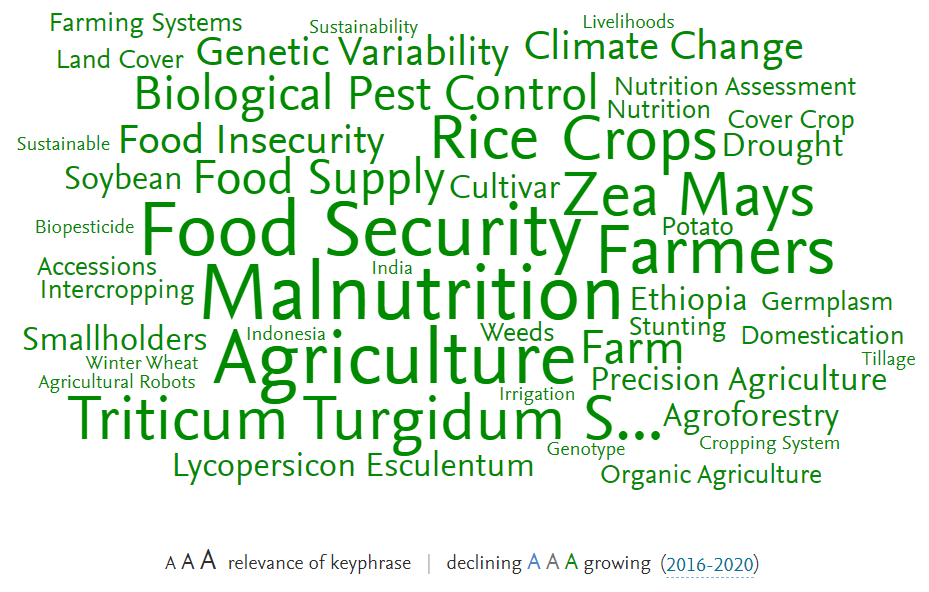

Explore this wordcloud plus the most active contributors on the [SciVal SDG site](https://scival.com/sdg)

## Query

Below is the full search query used for this SDG. We’ve broken it down by each query component. Use the + and – to concatenate the different bracket levels.

(

(

(

TITLE-ABS

(

"smallholder agriculture"

)

OR AUTHKEY

(

"smallholder agriculture"

)

OR

(

(TITLE-ABS("small-scale fishing") AND (TITLE-ABS("productivit*") OR TITLE-ABS("performanc*") OR TITLE-ABS("sustainab") OR TITLE-ABS("yield*") OR TITLE-ABS("profit*") OR TITLE-ABS("cash* crop*") OR TITLE-ABS("food* secur*") OR TITLE-ABS("income"))) OR (TITLE-ABS("smallscale fishing") AND (TITLE-ABS("productivit*") OR TITLE-ABS("performanc*") OR TITLE-ABS("sustainab") OR TITLE-ABS("yield*") OR TITLE-ABS("profit*") OR TITLE-ABS("cash* crop*") OR TITLE-ABS("food* secur*") OR TITLE-ABS("income")))

)

OR

(

(AUTHKEY("small-scale fishing") AND (AUTHKEY("productivit*") OR AUTHKEY("performanc*") OR AUTHKEY("sustainab") OR AUTHKEY("yield*") OR AUTHKEY("profit*") OR AUTHKEY("cash* crop*") OR AUTHKEY("food* secur*") OR AUTHKEY("income"))) OR (AUTHKEY("smallscale fishing") AND (AUTHKEY("productivit*") OR AUTHKEY("performanc*") OR AUTHKEY("sustainab") OR AUTHKEY("yield*") OR AUTHKEY("profit*") OR AUTHKEY("cash* crop*") OR AUTHKEY("food* secur*") OR AUTHKEY("income")))

)

OR TITLE-ABS

(

"smallholder dairy farmers"

)

OR AUTHKEY

(

"smallholder dairy farmers"

)

OR

(

(TITLE-ABS("small-scale farms") AND (TITLE-ABS("productivit*") OR TITLE-ABS("performanc*") OR TITLE-ABS("sustainab") OR TITLE-ABS("yield*") OR TITLE-ABS("profit*") OR TITLE-ABS("cash* crop*") OR TITLE-ABS("food* secur*") OR TITLE-ABS("income"))) OR (TITLE-ABS("smallscale farms") AND (TITLE-ABS("productivit*") OR TITLE-ABS("performanc*") OR TITLE-ABS("sustainab") OR TITLE-ABS("yield*") OR TITLE-ABS("profit*") OR TITLE-ABS("cash* crop*") OR TITLE-ABS("food* secur*") OR TITLE-ABS("income")))

)

OR

(

(AUTHKEY("small-scale farms") AND (AUTHKEY("productivit*") OR AUTHKEY("performanc*") OR AUTHKEY("sustainab") OR AUTHKEY("yield*") OR AUTHKEY("profit*") OR AUTHKEY("cash* crop*") OR AUTHKEY("food* secur*") OR AUTHKEY("income"))) OR (AUTHKEY("smallscale farms") AND (AUTHKEY("productivit*") OR AUTHKEY("performanc*") OR AUTHKEY("sustainab") OR AUTHKEY("yield*") OR AUTHKEY("profit*") OR AUTHKEY("cash* crop*") OR AUTHKEY("food* secur*") OR AUTHKEY("income")))

)

OR

(

TITLE-ABS("subsistence farming") AND (TITLE-ABS("productivit*") OR TITLE-ABS("performanc*") OR TITLE-ABS("sustainab") OR TITLE-ABS("yield*") OR TITLE-ABS("profit*") OR TITLE-ABS("cash* crop*") OR TITLE-ABS("food* secur*") OR TITLE-ABS("income"))

)

OR

(

AUTHKEY("subsistence farming") AND (AUTHKEY("productivit*") OR AUTHKEY("performanc*") OR AUTHKEY("sustainab") OR AUTHKEY("yield*") OR AUTHKEY("profit*") OR AUTHKEY("cash* crop*") OR AUTHKEY("food* secur*") OR AUTHKEY("income"))

)

OR

(

TITLE-ABS("smallholder") AND (TITLE-ABS("productivit*") OR TITLE-ABS("performanc*") OR TITLE-ABS("sustainab") OR TITLE-ABS("yield*") OR TITLE-ABS("profit*") OR TITLE-ABS("cash* crop*") OR TITLE-ABS("food* secur*") OR TITLE-ABS("income"))

)

OR

(

AUTHKEY("smallholder") AND (AUTHKEY("productivit*") OR AUTHKEY("performanc*") OR AUTHKEY("sustainab") OR AUTHKEY("yield*") OR AUTHKEY("profit*") OR AUTHKEY("cash* crop*") OR AUTHKEY("food* secur*") OR AUTHKEY("income"))

)

OR

(

TITLE-ABS("farming households") AND (TITLE-ABS("productivit*") OR TITLE-ABS("performanc*") OR TITLE-ABS("sustainab") OR TITLE-ABS("yield*") OR TITLE-ABS("profit*") OR TITLE-ABS("cash* crop*") OR TITLE-ABS("food* secur*") OR TITLE-ABS("income"))

)

OR

(

AUTHKEY("farming households") AND (AUTHKEY("productivit*") OR AUTHKEY("performanc*") OR AUTHKEY("sustainab") OR AUTHKEY("yield*") OR AUTHKEY("profit*") OR AUTHKEY("cash* crop*") OR AUTHKEY("food* secur*") OR AUTHKEY("income"))

)

OR

(

(TITLE-ABS("small*-scale* food*") AND TITLE-ABS("production")) OR (TITLE-ABS("smallscale* food*") AND TITLE-ABS("production"))

)

OR

(

(AUTHKEY("small*-scale* food*") AND AUTHKEY("production")) OR (AUTHKEY("smallscale* food*") AND AUTHKEY("production"))

)

OR

(

TITLE-ABS("small scale farm") AND (TITLE-ABS("productivit*") OR TITLE-ABS("performanc*") OR TITLE-ABS("sustainab") OR TITLE-ABS("yield*") OR TITLE-ABS("profit*") OR TITLE-ABS("cash* crop*") OR TITLE-ABS("food* secur*") OR TITLE-ABS("income"))

)

OR

(

AUTHKEY("small scale farm") AND (AUTHKEY("productivit*") OR AUTHKEY("performanc*") OR AUTHKEY("sustainab") OR AUTHKEY("yield*") OR AUTHKEY("profit*") OR AUTHKEY("cash* crop*") OR AUTHKEY("food* secur*") OR AUTHKEY("income"))

)

OR

(

((TITLE-ABS("Financial* support*") OR TITLE-ABS("financial* aid*") OR TITLE-ABS("financial* service*") OR TITLE-ABS("micro* finance*") OR TITLE-ABS("micro* credit*") OR TITLE-ABS("micro* lend*") OR TITLE-ABS("access* to* financ*") OR TITLE-ABS("financing") OR TITLE-ABS("economic empowerment") OR TITLE-ABS("financial* barrier*") OR TITLE-ABS("rural* financ*")) AND (TITLE-ABS("Small* farm*") OR TITLE-ABS("small* scale* farm*") OR TITLE-ABS("small* holder* farm*") OR TITLE-ABS("agro* pastoral*") OR TITLE-ABS("small* farm* household*") OR TITLE-ABS("poor* farm*") OR TITLE-ABS("pastoralist*") OR TITLE-ABS("asset*-poor* household*") OR TITLE-ABS("asset*-poor* famil*") OR TITLE-ABS("small* producer*"))) OR ((TITLE-ABS("Financial* support*") OR TITLE-ABS("financial* aid*") OR TITLE-ABS("financial* service*") OR TITLE-ABS("micro* finance*") OR TITLE-ABS("micro* credit*") OR TITLE-ABS("micro* lend*") OR TITLE-ABS("access* to* financ*") OR TITLE-ABS("financing") OR TITLE-ABS("economic empowerment") OR TITLE-ABS("financial* barrier*") OR TITLE-ABS("rural* financ*")) AND (TITLE-ABS("Small* farm*") OR TITLE-ABS("small* scale* farm*") OR TITLE-ABS("small* holder* farm*") OR TITLE-ABS("agro* pastoral*") OR TITLE-ABS("small* farm* household*") OR TITLE-ABS("poor* farm*") OR TITLE-ABS("pastoralist*") OR TITLE-ABS("assetpoor* household*") OR TITLE-ABS("assetpoor* famil*") OR TITLE-ABS("small* producer*")))

)

OR

(

((AUTHKEY("Financial* support*") OR AUTHKEY("financial* aid*") OR AUTHKEY("financial* service*") OR AUTHKEY("micro* finance*") OR AUTHKEY("micro* credit*") OR AUTHKEY("micro* lend*") OR AUTHKEY("access* to* financ*") OR AUTHKEY("financing") OR AUTHKEY("economic empowerment") OR AUTHKEY("financial* barrier*") OR AUTHKEY("rural* financ*")) AND (AUTHKEY("Small* farm*") OR AUTHKEY("small* scale* farm*") OR AUTHKEY("small* holder* farm*") OR AUTHKEY("agro* pastoral*") OR AUTHKEY("small* farm* household*") OR AUTHKEY("poor* farm*") OR AUTHKEY("pastoralist*") OR AUTHKEY("asset*-poor* household*") OR AUTHKEY("asset*-poor* famil*") OR AUTHKEY("small* producer*"))) OR ((AUTHKEY("Financial* support*") OR AUTHKEY("financial* aid*") OR AUTHKEY("financial* service*") OR AUTHKEY("micro* finance*") OR AUTHKEY("micro* credit*") OR AUTHKEY("micro* lend*") OR AUTHKEY("access* to* financ*") OR AUTHKEY("financing") OR AUTHKEY("economic empowerment") OR AUTHKEY("financial* barrier*") OR AUTHKEY("rural* financ*")) AND (AUTHKEY("Small* farm*") OR AUTHKEY("small* scale* farm*") OR AUTHKEY("small* holder* farm*") OR AUTHKEY("agro* pastoral*") OR AUTHKEY("small* farm* household*") OR AUTHKEY("poor* farm*") OR AUTHKEY("pastoralist*") OR AUTHKEY("assetpoor* household*") OR AUTHKEY("assetpoor* famil*") OR AUTHKEY("small* producer*")))

)

OR

(

TITLE-ABS("herd*") AND (TITLE-ABS("livelihood*") OR TITLE-ABS("household*"))

)

OR

(

AUTHKEY("herd*") AND (AUTHKEY("livelihood*") OR AUTHKEY("household*"))

)

OR TITLE-ABS

(

"smallholder farming"

)

OR AUTHKEY

(

"smallholder farming"

)

OR

(

TITLE-ABS("small-scale farmers") OR TITLE-ABS("smallscale farmers")

)

OR

(

AUTHKEY("small-scale farmers") OR AUTHKEY("smallscale farmers")

)

OR

(

TITLE-ABS("smallholders") AND (TITLE-ABS("productivit*") OR TITLE-ABS("performanc*") OR TITLE-ABS("sustainab") OR TITLE-ABS("yield*") OR TITLE-ABS("profit*") OR TITLE-ABS("cash* crop*") OR TITLE-ABS("food* secur*") OR TITLE-ABS("income"))

)

OR

(

AUTHKEY("smallholders") AND (AUTHKEY("productivit*") OR AUTHKEY("performanc*") OR AUTHKEY("sustainab") OR AUTHKEY("yield*") OR AUTHKEY("profit*") OR AUTHKEY("cash* crop*") OR AUTHKEY("food* secur*") OR AUTHKEY("income"))

)

OR

(

(TITLE-ABS("small-scale fishery") AND (TITLE-ABS("productivit*") OR TITLE-ABS("performanc*") OR TITLE-ABS("sustainab") OR TITLE-ABS("yield*") OR TITLE-ABS("profit*") OR TITLE-ABS("cash* crop*") OR TITLE-ABS("food* secur*") OR TITLE-ABS("income"))) OR (TITLE-ABS("smallscale fishery") AND (TITLE-ABS("productivit*") OR TITLE-ABS("performanc*") OR TITLE-ABS("sustainab") OR TITLE-ABS("yield*") OR TITLE-ABS("profit*") OR TITLE-ABS("cash* crop*") OR TITLE-ABS("food* secur*") OR TITLE-ABS("income")))

)

OR

(

(AUTHKEY("small-scale fishery") AND (AUTHKEY("productivit*") OR AUTHKEY("performanc*") OR AUTHKEY("sustainab") OR AUTHKEY("yield*") OR AUTHKEY("profit*") OR AUTHKEY("cash* crop*") OR AUTHKEY("food* secur*") OR AUTHKEY("income"))) OR (AUTHKEY("smallscale fishery") AND (AUTHKEY("productivit*") OR AUTHKEY("performanc*") OR AUTHKEY("sustainab") OR AUTHKEY("yield*") OR AUTHKEY("profit*") OR AUTHKEY("cash* crop*") OR AUTHKEY("food* secur*") OR AUTHKEY("income")))

)

OR TITLE-ABS

(

"smallholder dairy farms"

)

OR AUTHKEY

(

"smallholder dairy farms"

)

OR

(

(TITLE-ABS("small-scale farmers") AND (TITLE-ABS("productivit*") OR TITLE-ABS("performanc*") OR TITLE-ABS("sustainab") OR TITLE-ABS("yield*") OR TITLE-ABS("profit*") OR TITLE-ABS("cash* crop*") OR TITLE-ABS("food* secur*") OR TITLE-ABS("income"))) OR (TITLE-ABS("smallscale farmers") AND (TITLE-ABS("productivit*") OR TITLE-ABS("performanc*") OR TITLE-ABS("sustainab") OR TITLE-ABS("yield*") OR TITLE-ABS("profit*") OR TITLE-ABS("cash* crop*") OR TITLE-ABS("food* secur*") OR TITLE-ABS("income")))

)

OR

(

(AUTHKEY("small-scale farmers") AND (AUTHKEY("productivit*") OR AUTHKEY("performanc*") OR AUTHKEY("sustainab") OR AUTHKEY("yield*") OR AUTHKEY("profit*") OR AUTHKEY("cash* crop*") OR AUTHKEY("food* secur*") OR AUTHKEY("income"))) OR (AUTHKEY("smallscale farmers") AND (AUTHKEY("productivit*") OR AUTHKEY("performanc*") OR AUTHKEY("sustainab") OR AUTHKEY("yield*") OR AUTHKEY("profit*") OR AUTHKEY("cash* crop*") OR AUTHKEY("food* secur*") OR AUTHKEY("income")))

)

OR

(

TITLE-ABS("small scale farms") AND (TITLE-ABS("productivit*") OR TITLE-ABS("performanc*") OR TITLE-ABS("sustainab") OR TITLE-ABS("yield*") OR TITLE-ABS("profit*") OR TITLE-ABS("cash* crop*") OR TITLE-ABS("food* secur*") OR TITLE-ABS("income"))

)

OR

(

AUTHKEY("small scale farms") AND (AUTHKEY("productivit*") OR AUTHKEY("performanc*") OR AUTHKEY("sustainab") OR AUTHKEY("yield*") OR AUTHKEY("profit*") OR AUTHKEY("cash* crop*") OR AUTHKEY("food* secur*") OR AUTHKEY("income"))

)

OR

(

(TITLE-ABS("small-scale growers") AND (TITLE-ABS("productivit*") OR TITLE-ABS("performanc*") OR TITLE-ABS("sustainab") OR TITLE-ABS("yield*") OR TITLE-ABS("profit*") OR TITLE-ABS("cash* crop*") OR TITLE-ABS("food* secur*") OR TITLE-ABS("income"))) OR (TITLE-ABS("smallscale growers") AND (TITLE-ABS("productivit*") OR TITLE-ABS("performanc*") OR TITLE-ABS("sustainab") OR TITLE-ABS("yield*") OR TITLE-ABS("profit*") OR TITLE-ABS("cash* crop*") OR TITLE-ABS("food* secur*") OR TITLE-ABS("income")))

)

OR

(

(AUTHKEY("small-scale growers") AND (AUTHKEY("productivit*") OR AUTHKEY("performanc*") OR AUTHKEY("sustainab") OR AUTHKEY("yield*") OR AUTHKEY("profit*") OR AUTHKEY("cash* crop*") OR AUTHKEY("food* secur*") OR AUTHKEY("income"))) OR (AUTHKEY("smallscale growers") AND (AUTHKEY("productivit*") OR AUTHKEY("performanc*") OR AUTHKEY("sustainab") OR AUTHKEY("yield*") OR AUTHKEY("profit*") OR AUTHKEY("cash* crop*") OR AUTHKEY("food* secur*") OR AUTHKEY("income")))

)

OR

(

TITLE-ABS("farm households") AND (TITLE-ABS("productivit*") OR TITLE-ABS("performanc*") OR TITLE-ABS("sustainab") OR TITLE-ABS("yield*") OR TITLE-ABS("profit*") OR TITLE-ABS("cash* crop*") OR TITLE-ABS("food* secur*") OR TITLE-ABS("income"))

)

OR

(

AUTHKEY("farm households") AND (AUTHKEY("productivit*") OR AUTHKEY("performanc*") OR AUTHKEY("sustainab") OR AUTHKEY("yield*") OR AUTHKEY("profit*") OR AUTHKEY("cash* crop*") OR AUTHKEY("food* secur*") OR AUTHKEY("income"))

)

OR TITLE-ABS

(

"oil palm smallholders"

)

OR AUTHKEY

(

"oil palm smallholders"

)

OR

(

TITLE-ABS("scale farming") AND (TITLE-ABS("productivit*") OR TITLE-ABS("performanc*") OR TITLE-ABS("sustainab") OR TITLE-ABS("yield*") OR TITLE-ABS("profit*") OR TITLE-ABS("cash* crop*") OR TITLE-ABS("food* secur*") OR TITLE-ABS("income"))

)

OR

(

AUTHKEY("scale farming") AND (AUTHKEY("productivit*") OR AUTHKEY("performanc*") OR AUTHKEY("sustainab") OR AUTHKEY("yield*") OR AUTHKEY("profit*") OR AUTHKEY("cash* crop*") OR AUTHKEY("food* secur*") OR AUTHKEY("income"))

)

OR

(

TITLE-ABS("small* farm*") AND TITLE-ABS("additional* source*") AND (TITLE-ABS("revenue*") OR TITLE-ABS("income"))

)

OR

(

AUTHKEY("small* farm*") AND AUTHKEY("additional* source*") AND (AUTHKEY("revenue*") OR AUTHKEY("income"))

)

OR TITLE-ABS

(

"smallholder dairy"

)

OR AUTHKEY

(

"smallholder dairy"

)

OR

(

TITLE-ABS("fishing* household*") AND (TITLE-ABS("productivit*") OR TITLE-ABS("performanc*") OR TITLE-ABS("sustainab") OR TITLE-ABS("yield*") OR TITLE-ABS("profit*") OR TITLE-ABS("cash* crop*") OR TITLE-ABS("food* secur*") OR TITLE-ABS("income"))

)

OR

(

AUTHKEY("fishing* household*") AND (AUTHKEY("productivit*") OR AUTHKEY("performanc*") OR AUTHKEY("sustainab") OR AUTHKEY("yield*") OR AUTHKEY("profit*") OR AUTHKEY("cash* crop*") OR AUTHKEY("food* secur*") OR AUTHKEY("income"))

)

OR TITLE-ABS

(

"small farmers"

)

OR AUTHKEY

(

"small farmers"

)

OR

(

(TITLE-ABS("small-scale dairy") AND (TITLE-ABS("productivit*") OR TITLE-ABS("performanc*") OR TITLE-ABS("sustainab") OR TITLE-ABS("yield*") OR TITLE-ABS("profit*") OR TITLE-ABS("cash* crop*") OR TITLE-ABS("food* secur*") OR TITLE-ABS("income"))) OR (TITLE-ABS("smallscale dairy") AND (TITLE-ABS("productivit*") OR TITLE-ABS("performanc*") OR TITLE-ABS("sustainab") OR TITLE-ABS("yield*") OR TITLE-ABS("profit*") OR TITLE-ABS("cash* crop*") OR TITLE-ABS("food* secur*") OR TITLE-ABS("income")))

)

OR

(

(AUTHKEY("small-scale dairy") AND (AUTHKEY("productivit*") OR AUTHKEY("performanc*") OR AUTHKEY("sustainab") OR AUTHKEY("yield*") OR AUTHKEY("profit*") OR AUTHKEY("cash* crop*") OR AUTHKEY("food* secur*") OR AUTHKEY("income"))) OR (AUTHKEY("smallscale dairy") AND (AUTHKEY("productivit*") OR AUTHKEY("performanc*") OR AUTHKEY("sustainab") OR AUTHKEY("yield*") OR AUTHKEY("profit*") OR AUTHKEY("cash* crop*") OR AUTHKEY("food* secur*") OR AUTHKEY("income")))

)

OR

(

(TITLE-ABS("small-scale forest") AND (TITLE-ABS("productivit*") OR TITLE-ABS("performanc*") OR TITLE-ABS("sustainab") OR TITLE-ABS("yield*") OR TITLE-ABS("profit*") OR TITLE-ABS("cash* crop*") OR TITLE-ABS("food* secur*") OR TITLE-ABS("income"))) OR (TITLE-ABS("smallscale forest") AND (TITLE-ABS("productivit*") OR TITLE-ABS("performanc*") OR TITLE-ABS("sustainab") OR TITLE-ABS("yield*") OR TITLE-ABS("profit*") OR TITLE-ABS("cash* crop*") OR TITLE-ABS("food* secur*") OR TITLE-ABS("income")))

)

OR

(

(AUTHKEY("small-scale forest") AND (AUTHKEY("productivit*") OR AUTHKEY("performanc*") OR AUTHKEY("sustainab") OR AUTHKEY("yield*") OR AUTHKEY("profit*") OR AUTHKEY("cash* crop*") OR AUTHKEY("food* secur*") OR AUTHKEY("income"))) OR (AUTHKEY("smallscale forest") AND (AUTHKEY("productivit*") OR AUTHKEY("performanc*") OR AUTHKEY("sustainab") OR AUTHKEY("yield*") OR AUTHKEY("profit*") OR AUTHKEY("cash* crop*") OR AUTHKEY("food* secur*") OR AUTHKEY("income")))

)

OR

(

(TITLE-ABS("small-scale farming") AND (TITLE-ABS("productivit*") OR TITLE-ABS("performanc*") OR TITLE-ABS("sustainab") OR TITLE-ABS("yield*") OR TITLE-ABS("profit*") OR TITLE-ABS("cash* crop*") OR TITLE-ABS("food* secur*") OR TITLE-ABS("income"))) OR (TITLE-ABS("smallscale farming") AND (TITLE-ABS("productivit*") OR TITLE-ABS("performanc*") OR TITLE-ABS("sustainab") OR TITLE-ABS("yield*") OR TITLE-ABS("profit*") OR TITLE-ABS("cash* crop*") OR TITLE-ABS("food* secur*") OR TITLE-ABS("income")))

)

OR

(

(AUTHKEY("small-scale farming") AND (AUTHKEY("productivit*") OR AUTHKEY("performanc*") OR AUTHKEY("sustainab") OR AUTHKEY("yield*") OR AUTHKEY("profit*") OR AUTHKEY("cash* crop*") OR AUTHKEY("food* secur*") OR AUTHKEY("income"))) OR (AUTHKEY("smallscale farming") AND (AUTHKEY("productivit*") OR AUTHKEY("performanc*") OR AUTHKEY("sustainab") OR AUTHKEY("yield*") OR AUTHKEY("profit*") OR AUTHKEY("cash* crop*") OR AUTHKEY("food* secur*") OR AUTHKEY("income")))

)

OR

(

TITLE-ABS("small scale fisheries") AND (TITLE-ABS("productivit*") OR TITLE-ABS("performanc*") OR TITLE-ABS("sustainab") OR TITLE-ABS("yield*") OR TITLE-ABS("profit*") OR TITLE-ABS("cash* crop*") OR TITLE-ABS("food* secur*") OR TITLE-ABS("income"))

)

OR

(

AUTHKEY("small scale fisheries") AND (AUTHKEY("productivit*") OR AUTHKEY("performanc*") OR AUTHKEY("sustainab") OR AUTHKEY("yield*") OR AUTHKEY("profit*") OR AUTHKEY("cash* crop*") OR AUTHKEY("food* secur*") OR AUTHKEY("income"))

)

OR TITLE-ABS

(

"smallholder dairy farming"

)

OR AUTHKEY

(

"smallholder dairy farming"

)

OR

(

TITLE-ABS("small farmers") AND (TITLE-ABS("productivit*") OR TITLE-ABS("performanc*") OR TITLE-ABS("sustainab") OR TITLE-ABS("yield*") OR TITLE-ABS("profit*") OR TITLE-ABS("cash* crop*") OR TITLE-ABS("food* secur*") OR TITLE-ABS("income"))

)

OR

(

AUTHKEY("small farmers") AND (AUTHKEY("productivit*") OR AUTHKEY("performanc*") OR AUTHKEY("sustainab") OR AUTHKEY("yield*") OR AUTHKEY("profit*") OR AUTHKEY("cash* crop*") OR AUTHKEY("food* secur*") OR AUTHKEY("income"))

)

OR TITLE-ABS

(

"smallholder agroforestry"

)

OR AUTHKEY

(

"smallholder agroforestry"

)

OR

(

TITLE-ABS("pastoralism") AND TITLE-ABS("livelihood*")

)

OR

(

AUTHKEY("pastoralism") AND AUTHKEY("livelihood*")

)

OR

(

TITLE-ABS("agropastoral") AND (TITLE-ABS("productivit*") OR TITLE-ABS("performanc*") OR TITLE-ABS("sustainab") OR TITLE-ABS("yield*") OR TITLE-ABS("profit*") OR TITLE-ABS("cash* crop*") OR TITLE-ABS("food* secur*") OR TITLE-ABS("income"))

)

OR

(

AUTHKEY("agropastoral") AND (AUTHKEY("productivit*") OR AUTHKEY("performanc*") OR AUTHKEY("sustainab") OR AUTHKEY("yield*") OR AUTHKEY("profit*") OR AUTHKEY("cash* crop*") OR AUTHKEY("food* secur*") OR AUTHKEY("income"))

)

OR

(

TITLE-ABS("pastoralism") AND (TITLE-ABS("productivit*") OR TITLE-ABS("performanc*") OR TITLE-ABS("sustainab") OR TITLE-ABS("yield*") OR TITLE-ABS("profit*") OR TITLE-ABS("cash* crop*") OR TITLE-ABS("food* secur*") OR TITLE-ABS("income"))

)

OR

(

AUTHKEY("pastoralism") AND (AUTHKEY("productivit*") OR AUTHKEY("performanc*") OR AUTHKEY("sustainab") OR AUTHKEY("yield*") OR AUTHKEY("profit*") OR AUTHKEY("cash* crop*") OR AUTHKEY("food* secur*") OR AUTHKEY("income"))

)

OR

(

(TITLE-ABS("small-scale farm") AND (TITLE-ABS("productivit*") OR TITLE-ABS("performanc*") OR TITLE-ABS("sustainab") OR TITLE-ABS("yield*") OR TITLE-ABS("profit*") OR TITLE-ABS("cash* crop*") OR TITLE-ABS("food* secur*") OR TITLE-ABS("income"))) OR (TITLE-ABS("smallscale farm") AND (TITLE-ABS("productivit*") OR TITLE-ABS("performanc*") OR TITLE-ABS("sustainab") OR TITLE-ABS("yield*") OR TITLE-ABS("profit*") OR TITLE-ABS("cash* crop*") OR TITLE-ABS("food* secur*") OR TITLE-ABS("income")))

)

OR

(

(AUTHKEY("small-scale farm") AND (AUTHKEY("productivit*") OR AUTHKEY("performanc*") OR AUTHKEY("sustainab") OR AUTHKEY("yield*") OR AUTHKEY("profit*") OR AUTHKEY("cash* crop*") OR AUTHKEY("food* secur*") OR AUTHKEY("income"))) OR (AUTHKEY("smallscale farm") AND (AUTHKEY("productivit*") OR AUTHKEY("performanc*") OR AUTHKEY("sustainab") OR AUTHKEY("yield*") OR AUTHKEY("profit*") OR AUTHKEY("cash* crop*") OR AUTHKEY("food* secur*") OR AUTHKEY("income")))

)

OR TITLE-ABS

(

"smallholder farming systems"

)

OR AUTHKEY

(

"smallholder farming systems"

)

OR

(

(TITLE-ABS("small") AND TITLE-ABS("farm*")) AND TITLE-ABS("additional* source*") AND (TITLE-ABS("revenue*") OR TITLE-ABS("income"))

)

OR

(

(AUTHKEY("small") AND AUTHKEY("farm*")) AND AUTHKEY("additional* source*") AND (AUTHKEY("revenue*") OR AUTHKEY("income"))

)

OR

(

(TITLE-ABS("small-scale fish") AND (TITLE-ABS("productivit*") OR TITLE-ABS("performanc*") OR TITLE-ABS("sustainab") OR TITLE-ABS("yield*") OR TITLE-ABS("profit*") OR TITLE-ABS("cash* crop*") OR TITLE-ABS("food* secur*") OR TITLE-ABS("income"))) OR (TITLE-ABS("smallscale fish") AND (TITLE-ABS("productivit*") OR TITLE-ABS("performanc*") OR TITLE-ABS("sustainab") OR TITLE-ABS("yield*") OR TITLE-ABS("profit*") OR TITLE-ABS("cash* crop*") OR TITLE-ABS("food* secur*") OR TITLE-ABS("income")))

)

OR

(

(AUTHKEY("small-scale fish") AND (AUTHKEY("productivit*") OR AUTHKEY("performanc*") OR AUTHKEY("sustainab") OR AUTHKEY("yield*") OR AUTHKEY("profit*") OR AUTHKEY("cash* crop*") OR AUTHKEY("food* secur*") OR AUTHKEY("income"))) OR (AUTHKEY("smallscale fish") AND (AUTHKEY("productivit*") OR AUTHKEY("performanc*") OR AUTHKEY("sustainab") OR AUTHKEY("yield*") OR AUTHKEY("profit*") OR AUTHKEY("cash* crop*") OR AUTHKEY("food* secur*") OR AUTHKEY("income")))

)

OR TITLE-ABS

(

"smallholder systems"

)

OR AUTHKEY

(

"smallholder systems"

)

OR

(

TITLE-ABS("family labour") AND (TITLE-ABS("farm*") OR TITLE-ABS("agro*") OR TITLE-ABS("agri*"))

)

OR

(

AUTHKEY("family labour") AND (AUTHKEY("farm*") OR AUTHKEY("agro*") OR AUTHKEY("agri*"))

)

OR

(

TITLE-ABS("small scale farmers") AND (TITLE-ABS("productivit*") OR TITLE-ABS("performanc*") OR TITLE-ABS("sustainab") OR TITLE-ABS("yield*") OR TITLE-ABS("profit*") OR TITLE-ABS("cash* crop*") OR TITLE-ABS("food* secur*") OR TITLE-ABS("income"))

)

OR

(

AUTHKEY("small scale farmers") AND (AUTHKEY("productivit*") OR AUTHKEY("performanc*") OR AUTHKEY("sustainab") OR AUTHKEY("yield*") OR AUTHKEY("profit*") OR AUTHKEY("cash* crop*") OR AUTHKEY("food* secur*") OR AUTHKEY("income"))

)

OR TITLE-ABS

(

"smallholder cattle"

)

OR AUTHKEY

(

"smallholder cattle"

)

OR

(

(TITLE-ABS("silvo-pastoral") AND (TITLE-ABS("productivit*") OR TITLE-ABS("performanc*") OR TITLE-ABS("sustainab") OR TITLE-ABS("yield*") OR TITLE-ABS("profit*") OR TITLE-ABS("cash* crop*") OR TITLE-ABS("food* secur*") OR TITLE-ABS("income"))) OR (TITLE-ABS("silvopastoral") AND (TITLE-ABS("productivit*") OR TITLE-ABS("performanc*") OR TITLE-ABS("sustainab") OR TITLE-ABS("yield*") OR TITLE-ABS("profit*") OR TITLE-ABS("cash* crop*") OR TITLE-ABS("food* secur*") OR TITLE-ABS("income")))

)

OR

(

(AUTHKEY("silvo-pastoral") AND (AUTHKEY("productivit*") OR AUTHKEY("performanc*") OR AUTHKEY("sustainab") OR AUTHKEY("yield*") OR AUTHKEY("profit*") OR AUTHKEY("cash* crop*") OR AUTHKEY("food* secur*") OR AUTHKEY("income"))) OR (AUTHKEY("silvopastoral") AND (AUTHKEY("productivit*") OR AUTHKEY("performanc*") OR AUTHKEY("sustainab") OR AUTHKEY("yield*") OR AUTHKEY("profit*") OR AUTHKEY("cash* crop*") OR AUTHKEY("food* secur*") OR AUTHKEY("income")))

)

OR

(

TITLE-ABS("borana") AND (TITLE-ABS("productivit*") OR TITLE-ABS("performanc*") OR TITLE-ABS("sustainab") OR TITLE-ABS("yield*") OR TITLE-ABS("profit*") OR TITLE-ABS("cash* crop*") OR TITLE-ABS("food* secur*") OR TITLE-ABS("income"))

)

OR

(

AUTHKEY("borana") AND (AUTHKEY("productivit*") OR AUTHKEY("performanc*") OR AUTHKEY("sustainab") OR AUTHKEY("yield*") OR AUTHKEY("profit*") OR AUTHKEY("cash* crop*") OR AUTHKEY("food* secur*") OR AUTHKEY("income"))

)

OR

(

(TITLE-ABS("small") AND TITLE-ABS("farm*")) AND TITLE-ABS("pluriactivit*")

)

OR

(

(AUTHKEY("small") AND AUTHKEY("farm*")) AND AUTHKEY("pluriactivit*")

)

OR

(

TITLE-ABS("poor farmers") AND (TITLE-ABS("productivit*") OR TITLE-ABS("performanc*") OR TITLE-ABS("sustainab") OR TITLE-ABS("yield*") OR TITLE-ABS("profit*") OR TITLE-ABS("cash* crop*") OR TITLE-ABS("food* secur*") OR TITLE-ABS("income"))

)

OR

(

AUTHKEY("poor farmers") AND (AUTHKEY("productivit*") OR AUTHKEY("performanc*") OR AUTHKEY("sustainab") OR AUTHKEY("yield*") OR AUTHKEY("profit*") OR AUTHKEY("cash* crop*") OR AUTHKEY("food* secur*") OR AUTHKEY("income"))

)

OR

(

TITLE-ABS("maasai") AND (TITLE-ABS("productivit*") OR TITLE-ABS("performanc*") OR TITLE-ABS("sustainab") OR TITLE-ABS("yield*") OR TITLE-ABS("profit*") OR TITLE-ABS("cash* crop*") OR TITLE-ABS("food* secur*") OR TITLE-ABS("income"))

)

OR

(

AUTHKEY("maasai") AND (AUTHKEY("productivit*") OR AUTHKEY("performanc*") OR AUTHKEY("sustainab") OR AUTHKEY("yield*") OR AUTHKEY("profit*") OR AUTHKEY("cash* crop*") OR AUTHKEY("food* secur*") OR AUTHKEY("income"))

)

OR

(

(TITLE-ABS("small-scale farmer") AND (TITLE-ABS("productivit*") OR TITLE-ABS("performanc*") OR TITLE-ABS("sustainab") OR TITLE-ABS("yield*") OR TITLE-ABS("profit*") OR TITLE-ABS("cash* crop*") OR TITLE-ABS("food* secur*") OR TITLE-ABS("income"))) OR (TITLE-ABS("smallscale farmer") AND (TITLE-ABS("productivit*") OR TITLE-ABS("performanc*") OR TITLE-ABS("sustainab") OR TITLE-ABS("yield*") OR TITLE-ABS("profit*") OR TITLE-ABS("cash* crop*") OR TITLE-ABS("food* secur*") OR TITLE-ABS("income")))

)

OR

(

(AUTHKEY("small-scale farmer") AND (AUTHKEY("productivit*") OR AUTHKEY("performanc*") OR AUTHKEY("sustainab") OR AUTHKEY("yield*") OR AUTHKEY("profit*") OR AUTHKEY("cash* crop*") OR AUTHKEY("food* secur*") OR AUTHKEY("income"))) OR (AUTHKEY("smallscale farmer") AND (AUTHKEY("productivit*") OR AUTHKEY("performanc*") OR AUTHKEY("sustainab") OR AUTHKEY("yield*") OR AUTHKEY("profit*") OR AUTHKEY("cash* crop*") OR AUTHKEY("food* secur*") OR AUTHKEY("income")))

)

OR

(

TITLE-ABS("smallholdings") AND (TITLE-ABS("productivit*") OR TITLE-ABS("performanc*") OR TITLE-ABS("sustainab") OR TITLE-ABS("yield*") OR TITLE-ABS("profit*") OR TITLE-ABS("cash* crop*") OR TITLE-ABS("food* secur*") OR TITLE-ABS("income"))

)

OR

(

AUTHKEY("smallholdings") AND (AUTHKEY("productivit*") OR AUTHKEY("performanc*") OR AUTHKEY("sustainab") OR AUTHKEY("yield*") OR AUTHKEY("profit*") OR AUTHKEY("cash* crop*") OR AUTHKEY("food* secur*") OR AUTHKEY("income"))

)

OR TITLE-ABS

(

"smallholder irrigation"

)

OR AUTHKEY

(

"smallholder irrigation"

)

OR

(

(TITLE-ABS("small-scale irrigation") AND (TITLE-ABS("productivit*") OR TITLE-ABS("performanc*") OR TITLE-ABS("sustainab") OR TITLE-ABS("yield*") OR TITLE-ABS("profit*") OR TITLE-ABS("cash* crop*") OR TITLE-ABS("food* secur*") OR TITLE-ABS("income"))) OR (TITLE-ABS("smallscale irrigation") AND (TITLE-ABS("productivit*") OR TITLE-ABS("performanc*") OR TITLE-ABS("sustainab") OR TITLE-ABS("yield*") OR TITLE-ABS("profit*") OR TITLE-ABS("cash* crop*") OR TITLE-ABS("food* secur*") OR TITLE-ABS("income")))

)

OR

(

(AUTHKEY("small-scale irrigation") AND (AUTHKEY("productivit*") OR AUTHKEY("performanc*") OR AUTHKEY("sustainab") OR AUTHKEY("yield*") OR AUTHKEY("profit*") OR AUTHKEY("cash* crop*") OR AUTHKEY("food* secur*") OR AUTHKEY("income"))) OR (AUTHKEY("smallscale irrigation") AND (AUTHKEY("productivit*") OR AUTHKEY("performanc*") OR AUTHKEY("sustainab") OR AUTHKEY("yield*") OR AUTHKEY("profit*") OR AUTHKEY("cash* crop*") OR AUTHKEY("food* secur*") OR AUTHKEY("income")))

)

OR

(

(TITLE-ABS("small*-scale* food*") AND TITLE-ABS("production")) OR (TITLE-ABS("smallscale* food*") AND TITLE-ABS("production"))

)

OR

(

(AUTHKEY("small*-scale* food*") AND AUTHKEY("production")) OR (AUTHKEY("smallscale* food*") AND AUTHKEY("production"))

)

OR TITLE-ABS

(

"smallholder dairy production"

)

OR AUTHKEY

(

"smallholder dairy production"

)

OR TITLE-ABS

(

"smallholder production systems"

)

OR AUTHKEY

(

"smallholder production systems"

)

OR

(

(TITLE-ABS("small-scale fisher") AND (TITLE-ABS("productivit*") OR TITLE-ABS("performanc*") OR TITLE-ABS("sustainab") OR TITLE-ABS("yield*") OR TITLE-ABS("profit*") OR TITLE-ABS("cash* crop*") OR TITLE-ABS("food* secur*") OR TITLE-ABS("income"))) OR (TITLE-ABS("smallscale fisher") AND (TITLE-ABS("productivit*") OR TITLE-ABS("performanc*") OR TITLE-ABS("sustainab") OR TITLE-ABS("yield*") OR TITLE-ABS("profit*") OR TITLE-ABS("cash* crop*") OR TITLE-ABS("food* secur*") OR TITLE-ABS("income")))

)

OR

(

(AUTHKEY("small-scale fisher") AND (AUTHKEY("productivit*") OR AUTHKEY("performanc*") OR AUTHKEY("sustainab") OR AUTHKEY("yield*") OR AUTHKEY("profit*") OR AUTHKEY("cash* crop*") OR AUTHKEY("food* secur*") OR AUTHKEY("income"))) OR (AUTHKEY("smallscale fisher") AND (AUTHKEY("productivit*") OR AUTHKEY("performanc*") OR AUTHKEY("sustainab") OR AUTHKEY("yield*") OR AUTHKEY("profit*") OR AUTHKEY("cash* crop*") OR AUTHKEY("food* secur*") OR AUTHKEY("income")))

)

OR

(

(TITLE-ABS("resource-poor farmers") AND (TITLE-ABS("productivit*") OR TITLE-ABS("performanc*") OR TITLE-ABS("sustainab") OR TITLE-ABS("yield*") OR TITLE-ABS("profit*") OR TITLE-ABS("cash* crop*") OR TITLE-ABS("food* secur*") OR TITLE-ABS("income"))) OR (TITLE-ABS("resourcepoor farmers") AND (TITLE-ABS("productivit*") OR TITLE-ABS("performanc*") OR TITLE-ABS("sustainab") OR TITLE-ABS("yield*") OR TITLE-ABS("profit*") OR TITLE-ABS("cash* crop*") OR TITLE-ABS("food* secur*") OR TITLE-ABS("income")))

)

OR

(

(AUTHKEY("resource-poor farmers") AND (AUTHKEY("productivit*") OR AUTHKEY("performanc*") OR AUTHKEY("sustainab") OR AUTHKEY("yield*") OR AUTHKEY("profit*") OR AUTHKEY("cash* crop*") OR AUTHKEY("food* secur*") OR AUTHKEY("income"))) OR (AUTHKEY("resourcepoor farmers") AND (AUTHKEY("productivit*") OR AUTHKEY("performanc*") OR AUTHKEY("sustainab") OR AUTHKEY("yield*") OR AUTHKEY("profit*") OR AUTHKEY("cash* crop*") OR AUTHKEY("food* secur*") OR AUTHKEY("income")))

)

OR

(

TITLE-ABS("nomadic pastoralism") AND (TITLE-ABS("productivit*") OR TITLE-ABS("performanc*") OR TITLE-ABS("sustainab") OR TITLE-ABS("yield*") OR TITLE-ABS("profit*") OR TITLE-ABS("cash* crop*") OR TITLE-ABS("food* secur*") OR TITLE-ABS("income"))

)

OR

(

AUTHKEY("nomadic pastoralism") AND (AUTHKEY("productivit*") OR AUTHKEY("performanc*") OR AUTHKEY("sustainab") OR AUTHKEY("yield*") OR AUTHKEY("profit*") OR AUTHKEY("cash* crop*") OR AUTHKEY("food* secur*") OR AUTHKEY("income"))

)

OR

(

TITLE-ABS("pastora*") AND (TITLE-ABS("livelihood*") OR TITLE-ABS("household*"))

)

OR

(

AUTHKEY("pastora*") AND (AUTHKEY("livelihood*") OR AUTHKEY("household*"))

)

OR

(

TITLE-ABS("smallholder*") AND TITLE-ABS("product*") AND (TITLE-ABS("horti*") OR TITLE-ABS("vegetab*"))

)

OR

(

AUTHKEY("smallholder*") AND AUTHKEY("product*") AND (AUTHKEY("horti*") OR AUTHKEY("vegetab*"))

)

OR

(

(TITLE-ABS("agro-pastoralists") AND (TITLE-ABS("productivit*") OR TITLE-ABS("performanc*") OR TITLE-ABS("sustainab") OR TITLE-ABS("yield*") OR TITLE-ABS("profit*") OR TITLE-ABS("cash* crop*") OR TITLE-ABS("food* secur*") OR TITLE-ABS("income"))) OR (TITLE-ABS("agropastoralists") AND (TITLE-ABS("productivit*") OR TITLE-ABS("performanc*") OR TITLE-ABS("sustainab") OR TITLE-ABS("yield*") OR TITLE-ABS("profit*") OR TITLE-ABS("cash* crop*") OR TITLE-ABS("food* secur*") OR TITLE-ABS("income")))

)

OR

(

(AUTHKEY("agro-pastoralists") AND (AUTHKEY("productivit*") OR AUTHKEY("performanc*") OR AUTHKEY("sustainab") OR AUTHKEY("yield*") OR AUTHKEY("profit*") OR AUTHKEY("cash* crop*") OR AUTHKEY("food* secur*") OR AUTHKEY("income"))) OR (AUTHKEY("agropastoralists") AND (AUTHKEY("productivit*") OR AUTHKEY("performanc*") OR AUTHKEY("sustainab") OR AUTHKEY("yield*") OR AUTHKEY("profit*") OR AUTHKEY("cash* crop*") OR AUTHKEY("food* secur*") OR AUTHKEY("income")))

)

OR TITLE-ABS

(

"smallholder livestock"

)

OR AUTHKEY

(

"smallholder livestock"

)

OR

(

(TITLE-ABS("small-scale dairy farms") AND (TITLE-ABS("productivit*") OR TITLE-ABS("performanc*") OR TITLE-ABS("sustainab") OR TITLE-ABS("yield*") OR TITLE-ABS("profit*") OR TITLE-ABS("cash* crop*") OR TITLE-ABS("food* secur*") OR TITLE-ABS("income"))) OR (TITLE-ABS("smallscale dairy farms") AND (TITLE-ABS("productivit*") OR TITLE-ABS("performanc*") OR TITLE-ABS("sustainab") OR TITLE-ABS("yield*") OR TITLE-ABS("profit*") OR TITLE-ABS("cash* crop*") OR TITLE-ABS("food* secur*") OR TITLE-ABS("income")))

)

OR

(

(AUTHKEY("small-scale dairy farms") AND (AUTHKEY("productivit*") OR AUTHKEY("performanc*") OR AUTHKEY("sustainab") OR AUTHKEY("yield*") OR AUTHKEY("profit*") OR AUTHKEY("cash* crop*") OR AUTHKEY("food* secur*") OR AUTHKEY("income"))) OR (AUTHKEY("smallscale dairy farms") AND (AUTHKEY("productivit*") OR AUTHKEY("performanc*") OR AUTHKEY("sustainab") OR AUTHKEY("yield*") OR AUTHKEY("profit*") OR AUTHKEY("cash* crop*") OR AUTHKEY("food* secur*") OR AUTHKEY("income")))

)

OR

(

(TITLE-ABS("small-scale farming systems") AND (TITLE-ABS("productivit*") OR TITLE-ABS("performanc*") OR TITLE-ABS("sustainab") OR TITLE-ABS("yield*") OR TITLE-ABS("profit*") OR TITLE-ABS("cash* crop*") OR TITLE-ABS("food* secur*") OR TITLE-ABS("income"))) OR (TITLE-ABS("smallscale farming systems") AND (TITLE-ABS("productivit*") OR TITLE-ABS("performanc*") OR TITLE-ABS("sustainab") OR TITLE-ABS("yield*") OR TITLE-ABS("profit*") OR TITLE-ABS("cash* crop*") OR TITLE-ABS("food* secur*") OR TITLE-ABS("income")))

)

OR

(

(AUTHKEY("small-scale farming systems") AND (AUTHKEY("productivit*") OR AUTHKEY("performanc*") OR AUTHKEY("sustainab") OR AUTHKEY("yield*") OR AUTHKEY("profit*") OR AUTHKEY("cash* crop*") OR AUTHKEY("food* secur*") OR AUTHKEY("income"))) OR (AUTHKEY("smallscale farming systems") AND (AUTHKEY("productivit*") OR AUTHKEY("performanc*") OR AUTHKEY("sustainab") OR AUTHKEY("yield*") OR AUTHKEY("profit*") OR AUTHKEY("cash* crop*") OR AUTHKEY("food* secur*") OR AUTHKEY("income")))

)

OR TITLE-ABS

(

"smallholder coffee"

)

OR AUTHKEY

(

"smallholder coffee"

)

OR

(

TITLE-ABS("smallholder farmers") AND (TITLE-ABS("productivit*") OR TITLE-ABS("performanc*") OR TITLE-ABS("sustainab") OR TITLE-ABS("yield*") OR TITLE-ABS("profit*") OR TITLE-ABS("cash* crop*") OR TITLE-ABS("food* secur*") OR TITLE-ABS("income"))

)

OR

(

AUTHKEY("smallholder farmers") AND (AUTHKEY("productivit*") OR AUTHKEY("performanc*") OR AUTHKEY("sustainab") OR AUTHKEY("yield*") OR AUTHKEY("profit*") OR AUTHKEY("cash* crop*") OR AUTHKEY("food* secur*") OR AUTHKEY("income"))

)

OR

(

(TITLE-ABS("small*-hold*") AND TITLE-ABS("value-added processing")) OR (TITLE-ABS("smallhold*") AND TITLE-ABS("valueadded processing"))

)

OR

(

(AUTHKEY("small*-hold*") AND AUTHKEY("value-added processing")) OR (AUTHKEY("smallhold*") AND AUTHKEY("valueadded processing"))

)

OR TITLE-ABS

(

"small holder farmers"

)

OR AUTHKEY

(

"small holder farmers"

)

OR

(

TITLE-ABS("small farms") AND (TITLE-ABS("productivit*") OR TITLE-ABS("performanc*") OR TITLE-ABS("sustainab") OR TITLE-ABS("yield*") OR TITLE-ABS("profit*") OR TITLE-ABS("cash* crop*") OR TITLE-ABS("food* secur*") OR TITLE-ABS("income"))

)

OR

(

AUTHKEY("small farms") AND (AUTHKEY("productivit*") OR AUTHKEY("performanc*") OR AUTHKEY("sustainab") OR AUTHKEY("yield*") OR AUTHKEY("profit*") OR AUTHKEY("cash* crop*") OR AUTHKEY("food* secur*") OR AUTHKEY("income"))

)

OR

(

TITLE-ABS("small holder") AND (TITLE-ABS("productivit*") OR TITLE-ABS("performanc*") OR TITLE-ABS("sustainab") OR TITLE-ABS("yield*") OR TITLE-ABS("profit*") OR TITLE-ABS("cash* crop*") OR TITLE-ABS("food* secur*") OR TITLE-ABS("income"))

)

OR

(

AUTHKEY("small holder") AND (AUTHKEY("productivit*") OR AUTHKEY("performanc*") OR AUTHKEY("sustainab") OR AUTHKEY("yield*") OR AUTHKEY("profit*") OR AUTHKEY("cash* crop*") OR AUTHKEY("food* secur*") OR AUTHKEY("income"))

)

OR

(

TITLE-ABS("pastoralist") AND (TITLE-ABS("productivit*") OR TITLE-ABS("performanc*") OR TITLE-ABS("sustainab") OR TITLE-ABS("yield*") OR TITLE-ABS("profit*") OR TITLE-ABS("cash* crop*") OR TITLE-ABS("food* secur*") OR TITLE-ABS("income"))

)

OR

(

AUTHKEY("pastoralist") AND (AUTHKEY("productivit*") OR AUTHKEY("performanc*") OR AUTHKEY("sustainab") OR AUTHKEY("yield*") OR AUTHKEY("profit*") OR AUTHKEY("cash* crop*") OR AUTHKEY("food* secur*") OR AUTHKEY("income"))

)

OR

(

((TITLE-ABS("smallholder") OR TITLE-ABS("smallholders") OR TITLE-ABS("smallholder systems") OR TITLE-ABS("small holder") OR TITLE-ABS("smallholding") OR TITLE-ABS("small farms") OR TITLE-ABS("small-holder") OR TITLE-ABS("small farmers") OR TITLE-ABS("small farm") OR TITLE-ABS("small-scale farming") OR TITLE-ABS("small-scale agriculture") OR TITLE-ABS("small-farm") OR TITLE-ABS("small-holders") OR TITLE-ABS("small holders") OR TITLE-ABS("small producers") OR TITLE-ABS("small farmer") OR TITLE-ABS("small scale farmers") OR TITLE-ABS("small-scale farm") OR TITLE-ABS("small growers") OR TITLE-ABS("small scale farming") OR TITLE-ABS("small-scale farmer") OR TITLE-ABS("small scale farms") OR TITLE-ABS("small landholdings") OR TITLE-ABS("small-scale plantations") OR TITLE-ABS("small landholders") OR TITLE-ABS("small farming") OR TITLE-ABS("small producer") OR TITLE-ABS("small land holders") OR TITLE-ABS("small-farmer")) AND (TITLE-ABS("agriculture") OR TITLE-ABS("agricultural") OR TITLE-ABS("crop") OR TITLE-ABS("livestock") OR TITLE-ABS("crops") OR TITLE-ABS("maize") OR TITLE-ABS("agro") OR TITLE-ABS("soil fertility") OR TITLE-ABS("production systems") OR TITLE-ABS("dairy") OR TITLE-ABS("on-farm") OR TITLE-ABS("agricultural production") OR TITLE-ABS("cattle") OR TITLE-ABS("planting") OR TITLE-ABS("agroforestry") OR TITLE-ABS("cultivation") OR TITLE-ABS("irrigation") OR TITLE-ABS("crop production") OR TITLE-ABS("manure") OR TITLE-ABS("milk") OR TITLE-ABS("food production") OR TITLE-ABS("coffee") OR TITLE-ABS("pest") OR TITLE-ABS("cows") OR TITLE-ABS("agronomic") OR TITLE-ABS("rice") OR TITLE-ABS("cropping systems") OR TITLE-ABS("vegetable") OR TITLE-ABS("cultivated") OR TITLE-ABS("milk production") OR TITLE-ABS("dairy farms") OR TITLE-ABS("vegetables") OR TITLE-ABS("tillage") OR TITLE-ABS("legumes") OR TITLE-ABS("breeding") OR TITLE-ABS("irrigated") OR TITLE-ABS("feed") OR TITLE-ABS("goats") OR TITLE-ABS("forage") OR TITLE-ABS("legume") OR TITLE-ABS("farming") OR TITLE-ABS("soil"))) OR ((TITLE-ABS("smallholder") OR TITLE-ABS("smallholders") OR TITLE-ABS("smallholder systems") OR TITLE-ABS("small holder") OR TITLE-ABS("smallholding") OR TITLE-ABS("small farms") OR TITLE-ABS("smallholder") OR TITLE-ABS("small farmers") OR TITLE-ABS("small farm") OR TITLE-ABS("smallscale farming") OR TITLE-ABS("smallscale agriculture") OR TITLE-ABS("smallfarm") OR TITLE-ABS("smallholders") OR TITLE-ABS("small holders") OR TITLE-ABS("small producers") OR TITLE-ABS("small farmer") OR TITLE-ABS("small scale farmers") OR TITLE-ABS("smallscale farm") OR TITLE-ABS("small growers") OR TITLE-ABS("small scale farming") OR TITLE-ABS("smallscale farmer") OR TITLE-ABS("small scale farms") OR TITLE-ABS("small landholdings") OR TITLE-ABS("smallscale plantations") OR TITLE-ABS("small landholders") OR TITLE-ABS("small farming") OR TITLE-ABS("small producer") OR TITLE-ABS("small land holders") OR TITLE-ABS("smallfarmer")) AND (TITLE-ABS("agriculture") OR TITLE-ABS("agricultural") OR TITLE-ABS("crop") OR TITLE-ABS("livestock") OR TITLE-ABS("crops") OR TITLE-ABS("maize") OR TITLE-ABS("agro") OR TITLE-ABS("soil fertility") OR TITLE-ABS("production systems") OR TITLE-ABS("dairy") OR TITLE-ABS("onfarm") OR TITLE-ABS("agricultural production") OR TITLE-ABS("cattle") OR TITLE-ABS("planting") OR TITLE-ABS("agroforestry") OR TITLE-ABS("cultivation") OR TITLE-ABS("irrigation") OR TITLE-ABS("crop production") OR TITLE-ABS("manure") OR TITLE-ABS("milk") OR TITLE-ABS("food production") OR TITLE-ABS("coffee") OR TITLE-ABS("pest") OR TITLE-ABS("cows") OR TITLE-ABS("agronomic") OR TITLE-ABS("rice") OR TITLE-ABS("cropping systems") OR TITLE-ABS("vegetable") OR TITLE-ABS("cultivated") OR TITLE-ABS("milk production") OR TITLE-ABS("dairy farms") OR TITLE-ABS("vegetables") OR TITLE-ABS("tillage") OR TITLE-ABS("legumes") OR TITLE-ABS("breeding") OR TITLE-ABS("irrigated") OR TITLE-ABS("feed") OR TITLE-ABS("goats") OR TITLE-ABS("forage") OR TITLE-ABS("legume") OR TITLE-ABS("farming") OR TITLE-ABS("soil")))

)

OR

(

((AUTHKEY("smallholder") OR AUTHKEY("smallholders") OR AUTHKEY("smallholder systems") OR AUTHKEY("small holder") OR AUTHKEY("smallholding") OR AUTHKEY("small farms") OR AUTHKEY("small-holder") OR AUTHKEY("small farmers") OR AUTHKEY("small farm") OR AUTHKEY("small-scale farming") OR AUTHKEY("small-scale agriculture") OR AUTHKEY("small-farm") OR AUTHKEY("small-holders") OR AUTHKEY("small holders") OR AUTHKEY("small producers") OR AUTHKEY("small farmer") OR AUTHKEY("small scale farmers") OR AUTHKEY("small-scale farm") OR AUTHKEY("small growers") OR AUTHKEY("small scale farming") OR AUTHKEY("small-scale farmer") OR AUTHKEY("small scale farms") OR AUTHKEY("small landholdings") OR AUTHKEY("small-scale plantations") OR AUTHKEY("small landholders") OR AUTHKEY("small farming") OR AUTHKEY("small producer") OR AUTHKEY("small land holders") OR AUTHKEY("small-farmer")) AND (AUTHKEY("agriculture") OR AUTHKEY("agricultural") OR AUTHKEY("crop") OR AUTHKEY("livestock") OR AUTHKEY("crops") OR AUTHKEY("maize") OR AUTHKEY("agro") OR AUTHKEY("soil fertility") OR AUTHKEY("production systems") OR AUTHKEY("dairy") OR AUTHKEY("on-farm") OR AUTHKEY("agricultural production") OR AUTHKEY("cattle") OR AUTHKEY("planting") OR AUTHKEY("agroforestry") OR AUTHKEY("cultivation") OR AUTHKEY("irrigation") OR AUTHKEY("crop production") OR AUTHKEY("manure") OR AUTHKEY("milk") OR AUTHKEY("food production") OR AUTHKEY("coffee") OR AUTHKEY("pest") OR AUTHKEY("cows") OR AUTHKEY("agronomic") OR AUTHKEY("rice") OR AUTHKEY("cropping systems") OR AUTHKEY("vegetable") OR AUTHKEY("cultivated") OR AUTHKEY("milk production") OR AUTHKEY("dairy farms") OR AUTHKEY("vegetables") OR AUTHKEY("tillage") OR AUTHKEY("legumes") OR AUTHKEY("breeding") OR AUTHKEY("irrigated") OR AUTHKEY("feed") OR AUTHKEY("goats") OR AUTHKEY("forage") OR AUTHKEY("legume") OR AUTHKEY("farming") OR AUTHKEY("soil"))) OR ((AUTHKEY("smallholder") OR AUTHKEY("smallholders") OR AUTHKEY("smallholder systems") OR AUTHKEY("small holder") OR AUTHKEY("smallholding") OR AUTHKEY("small farms") OR AUTHKEY("smallholder") OR AUTHKEY("small farmers") OR AUTHKEY("small farm") OR AUTHKEY("smallscale farming") OR AUTHKEY("smallscale agriculture") OR AUTHKEY("smallfarm") OR AUTHKEY("smallholders") OR AUTHKEY("small holders") OR AUTHKEY("small producers") OR AUTHKEY("small farmer") OR AUTHKEY("small scale farmers") OR AUTHKEY("smallscale farm") OR AUTHKEY("small growers") OR AUTHKEY("small scale farming") OR AUTHKEY("smallscale farmer") OR AUTHKEY("small scale farms") OR AUTHKEY("small landholdings") OR AUTHKEY("smallscale plantations") OR AUTHKEY("small landholders") OR AUTHKEY("small farming") OR AUTHKEY("small producer") OR AUTHKEY("small land holders") OR AUTHKEY("smallfarmer")) AND (AUTHKEY("agriculture") OR AUTHKEY("agricultural") OR AUTHKEY("crop") OR AUTHKEY("livestock") OR AUTHKEY("crops") OR AUTHKEY("maize") OR AUTHKEY("agro") OR AUTHKEY("soil fertility") OR AUTHKEY("production systems") OR AUTHKEY("dairy") OR AUTHKEY("onfarm") OR AUTHKEY("agricultural production") OR AUTHKEY("cattle") OR AUTHKEY("planting") OR AUTHKEY("agroforestry") OR AUTHKEY("cultivation") OR AUTHKEY("irrigation") OR AUTHKEY("crop production") OR AUTHKEY("manure") OR AUTHKEY("milk") OR AUTHKEY("food production") OR AUTHKEY("coffee") OR AUTHKEY("pest") OR AUTHKEY("cows") OR AUTHKEY("agronomic") OR AUTHKEY("rice") OR AUTHKEY("cropping systems") OR AUTHKEY("vegetable") OR AUTHKEY("cultivated") OR AUTHKEY("milk production") OR AUTHKEY("dairy farms") OR AUTHKEY("vegetables") OR AUTHKEY("tillage") OR AUTHKEY("legumes") OR AUTHKEY("breeding") OR AUTHKEY("irrigated") OR AUTHKEY("feed") OR AUTHKEY("goats") OR AUTHKEY("forage") OR AUTHKEY("legume") OR AUTHKEY("farming") OR AUTHKEY("soil")))

)

OR

(

(TITLE-ABS("small-scale fisheries") AND (TITLE-ABS("productivit*") OR TITLE-ABS("performanc*") OR TITLE-ABS("sustainab") OR TITLE-ABS("yield*") OR TITLE-ABS("profit*") OR TITLE-ABS("cash* crop*") OR TITLE-ABS("food* secur*") OR TITLE-ABS("income"))) OR (TITLE-ABS("smallscale fisheries") AND (TITLE-ABS("productivit*") OR TITLE-ABS("performanc*") OR TITLE-ABS("sustainab") OR TITLE-ABS("yield*") OR TITLE-ABS("profit*") OR TITLE-ABS("cash* crop*") OR TITLE-ABS("food* secur*") OR TITLE-ABS("income")))

)

OR

(

(AUTHKEY("small-scale fisheries") AND (AUTHKEY("productivit*") OR AUTHKEY("performanc*") OR AUTHKEY("sustainab") OR AUTHKEY("yield*") OR AUTHKEY("profit*") OR AUTHKEY("cash* crop*") OR AUTHKEY("food* secur*") OR AUTHKEY("income"))) OR (AUTHKEY("smallscale fisheries") AND (AUTHKEY("productivit*") OR AUTHKEY("performanc*") OR AUTHKEY("sustainab") OR AUTHKEY("yield*") OR AUTHKEY("profit*") OR AUTHKEY("cash* crop*") OR AUTHKEY("food* secur*") OR AUTHKEY("income")))

)

OR

(

TITLE-ABS("herd*") AND TITLE-ABS("sustain*") AND TITLE-ABS("small?sc*")

)

OR

(

AUTHKEY("herd*") AND AUTHKEY("sustain*") AND AUTHKEY("small?sc*")

)

OR TITLE-ABS

(

"smallholder farm"

)

OR AUTHKEY

(

"smallholder farm"

)

OR

(

(TITLE-ABS("small-scale dairy systems") AND (TITLE-ABS("productivit*") OR TITLE-ABS("performanc*") OR TITLE-ABS("sustainab") OR TITLE-ABS("yield*") OR TITLE-ABS("profit*") OR TITLE-ABS("cash* crop*") OR TITLE-ABS("food* secur*") OR TITLE-ABS("income"))) OR (TITLE-ABS("smallscale dairy systems") AND (TITLE-ABS("productivit*") OR TITLE-ABS("performanc*") OR TITLE-ABS("sustainab") OR TITLE-ABS("yield*") OR TITLE-ABS("profit*") OR TITLE-ABS("cash* crop*") OR TITLE-ABS("food* secur*") OR TITLE-ABS("income")))

)

OR

(

(AUTHKEY("small-scale dairy systems") AND (AUTHKEY("productivit*") OR AUTHKEY("performanc*") OR AUTHKEY("sustainab") OR AUTHKEY("yield*") OR AUTHKEY("profit*") OR AUTHKEY("cash* crop*") OR AUTHKEY("food* secur*") OR AUTHKEY("income"))) OR (AUTHKEY("smallscale dairy systems") AND (AUTHKEY("productivit*") OR AUTHKEY("performanc*") OR AUTHKEY("sustainab") OR AUTHKEY("yield*") OR AUTHKEY("profit*") OR AUTHKEY("cash* crop*") OR AUTHKEY("food* secur*") OR AUTHKEY("income")))

)

OR TITLE-ABS

(

"smallholder farmer"

)

OR AUTHKEY

(

"smallholder farmer"

)

OR

(

(TITLE-ABS("agro-pastoral") AND (TITLE-ABS("productivit*") OR TITLE-ABS("performanc*") OR TITLE-ABS("sustainab") OR TITLE-ABS("yield*") OR TITLE-ABS("profit*") OR TITLE-ABS("cash* crop*") OR TITLE-ABS("food* secur*") OR TITLE-ABS("income"))) OR (TITLE-ABS("agropastoral") AND (TITLE-ABS("productivit*") OR TITLE-ABS("performanc*") OR TITLE-ABS("sustainab") OR TITLE-ABS("yield*") OR TITLE-ABS("profit*") OR TITLE-ABS("cash* crop*") OR TITLE-ABS("food* secur*") OR TITLE-ABS("income")))

)

OR

(

(AUTHKEY("agro-pastoral") AND (AUTHKEY("productivit*") OR AUTHKEY("performanc*") OR AUTHKEY("sustainab") OR AUTHKEY("yield*") OR AUTHKEY("profit*") OR AUTHKEY("cash* crop*") OR AUTHKEY("food* secur*") OR AUTHKEY("income"))) OR (AUTHKEY("agropastoral") AND (AUTHKEY("productivit*") OR AUTHKEY("performanc*") OR AUTHKEY("sustainab") OR AUTHKEY("yield*") OR AUTHKEY("profit*") OR AUTHKEY("cash* crop*") OR AUTHKEY("food* secur*") OR AUTHKEY("income")))

)

OR

(

(TITLE-ABS("small-scale forestry") AND (TITLE-ABS("productivit*") OR TITLE-ABS("performanc*") OR TITLE-ABS("sustainab") OR TITLE-ABS("yield*") OR TITLE-ABS("profit*") OR TITLE-ABS("cash* crop*") OR TITLE-ABS("food* secur*") OR TITLE-ABS("income"))) OR (TITLE-ABS("smallscale forestry") AND (TITLE-ABS("productivit*") OR TITLE-ABS("performanc*") OR TITLE-ABS("sustainab") OR TITLE-ABS("yield*") OR TITLE-ABS("profit*") OR TITLE-ABS("cash* crop*") OR TITLE-ABS("food* secur*") OR TITLE-ABS("income")))

)

OR

(

(AUTHKEY("small-scale forestry") AND (AUTHKEY("productivit*") OR AUTHKEY("performanc*") OR AUTHKEY("sustainab") OR AUTHKEY("yield*") OR AUTHKEY("profit*") OR AUTHKEY("cash* crop*") OR AUTHKEY("food* secur*") OR AUTHKEY("income"))) OR (AUTHKEY("smallscale forestry") AND (AUTHKEY("productivit*") OR AUTHKEY("performanc*") OR AUTHKEY("sustainab") OR AUTHKEY("yield*") OR AUTHKEY("profit*") OR AUTHKEY("cash* crop*") OR AUTHKEY("food* secur*") OR AUTHKEY("income")))

)

OR

(

TITLE-ABS("smallholder farming systems") AND (TITLE-ABS("productivit*") OR TITLE-ABS("performanc*") OR TITLE-ABS("sustainab") OR TITLE-ABS("yield*") OR TITLE-ABS("profit*") OR TITLE-ABS("cash* crop*") OR TITLE-ABS("food* secur*") OR TITLE-ABS("income"))

)

OR

(

AUTHKEY("smallholder farming systems") AND (AUTHKEY("productivit*") OR AUTHKEY("performanc*") OR AUTHKEY("sustainab") OR AUTHKEY("yield*") OR AUTHKEY("profit*") OR AUTHKEY("cash* crop*") OR AUTHKEY("food* secur*") OR AUTHKEY("income"))

)

OR

(

TITLE-ABS("small scale farming") AND (TITLE-ABS("productivit*") OR TITLE-ABS("performanc*") OR TITLE-ABS("sustainab") OR TITLE-ABS("yield*") OR TITLE-ABS("profit*") OR TITLE-ABS("cash* crop*") OR TITLE-ABS("food* secur*") OR TITLE-ABS("income"))

)

OR

(

AUTHKEY("small scale farming") AND (AUTHKEY("productivit*") OR AUTHKEY("performanc*") OR AUTHKEY("sustainab") OR AUTHKEY("yield*") OR AUTHKEY("profit*") OR AUTHKEY("cash* crop*") OR AUTHKEY("food* secur*") OR AUTHKEY("income"))

)

OR

(

TITLE-ABS("farm household") AND (TITLE-ABS("productivit*") OR TITLE-ABS("performanc*") OR TITLE-ABS("sustainab") OR TITLE-ABS("yield*") OR TITLE-ABS("profit*") OR TITLE-ABS("cash* crop*") OR TITLE-ABS("food* secur*") OR TITLE-ABS("income"))

)

OR

(

AUTHKEY("farm household") AND (AUTHKEY("productivit*") OR AUTHKEY("performanc*") OR AUTHKEY("sustainab") OR AUTHKEY("yield*") OR AUTHKEY("profit*") OR AUTHKEY("cash* crop*") OR AUTHKEY("food* secur*") OR AUTHKEY("income"))

)

OR

(

TITLE-ABS("small-holder farmers") OR TITLE-ABS("smallholder farmers")

)

OR

(

AUTHKEY("small-holder farmers") OR AUTHKEY("smallholder farmers")

)

OR

(

TITLE-ABS("pastoralist*") AND TITLE-ABS("indigenous vegetation") AND TITLE-ABS("grazing")

)

OR

(

AUTHKEY("pastoralist*") AND AUTHKEY("indigenous vegetation") AND AUTHKEY("grazing")

)

OR

(

TITLE-ABS("herders") AND (TITLE-ABS("productivit*") OR TITLE-ABS("performanc*") OR TITLE-ABS("sustainab") OR TITLE-ABS("yield*") OR TITLE-ABS("profit*") OR TITLE-ABS("cash* crop*") OR TITLE-ABS("food* secur*") OR TITLE-ABS("income"))

)

OR

(

AUTHKEY("herders") AND (AUTHKEY("productivit*") OR AUTHKEY("performanc*") OR AUTHKEY("sustainab") OR AUTHKEY("yield*") OR AUTHKEY("profit*") OR AUTHKEY("cash* crop*") OR AUTHKEY("food* secur*") OR AUTHKEY("income"))

)

OR

(

TITLE-ABS("pastoralists") AND (TITLE-ABS("productivit*") OR TITLE-ABS("performanc*") OR TITLE-ABS("sustainab") OR TITLE-ABS("yield*") OR TITLE-ABS("profit*") OR TITLE-ABS("cash* crop*") OR TITLE-ABS("food* secur*") OR TITLE-ABS("income"))

)

OR

(

AUTHKEY("pastoralists") AND (AUTHKEY("productivit*") OR AUTHKEY("performanc*") OR AUTHKEY("sustainab") OR AUTHKEY("yield*") OR AUTHKEY("profit*") OR AUTHKEY("cash* crop*") OR AUTHKEY("food* secur*") OR AUTHKEY("income"))

)

OR TITLE-ABS

(

"smallholder farms"

)

OR AUTHKEY

(

"smallholder farms"

)

OR TITLE-ABS

(

"smallholder farmers"

)

OR AUTHKEY

(

"smallholder farmers"

)

OR

(

(TITLE-ABS("small-scale agriculture") AND (TITLE-ABS("productivit*") OR TITLE-ABS("performanc*") OR TITLE-ABS("sustainab") OR TITLE-ABS("yield*") OR TITLE-ABS("profit*") OR TITLE-ABS("cash* crop*") OR TITLE-ABS("food* secur*") OR TITLE-ABS("income"))) OR (TITLE-ABS("smallscale agriculture") AND (TITLE-ABS("productivit*") OR TITLE-ABS("performanc*") OR TITLE-ABS("sustainab") OR TITLE-ABS("yield*") OR TITLE-ABS("profit*") OR TITLE-ABS("cash* crop*") OR TITLE-ABS("food* secur*") OR TITLE-ABS("income")))

)

OR

(

(AUTHKEY("small-scale agriculture") AND (AUTHKEY("productivit*") OR AUTHKEY("performanc*") OR AUTHKEY("sustainab") OR AUTHKEY("yield*") OR AUTHKEY("profit*") OR AUTHKEY("cash* crop*") OR AUTHKEY("food* secur*") OR AUTHKEY("income"))) OR (AUTHKEY("smallscale agriculture") AND (AUTHKEY("productivit*") OR AUTHKEY("performanc*") OR AUTHKEY("sustainab") OR AUTHKEY("yield*") OR AUTHKEY("profit*") OR AUTHKEY("cash* crop*") OR AUTHKEY("food* secur*") OR AUTHKEY("income")))

)

OR TITLE-ABS

(

"smallholder production"

)

OR AUTHKEY

(

"smallholder production"

)

OR

(

(TITLE-ABS("small-scale producers") AND (TITLE-ABS("productivit*") OR TITLE-ABS("performanc*") OR TITLE-ABS("sustainab") OR TITLE-ABS("yield*") OR TITLE-ABS("profit*") OR TITLE-ABS("cash* crop*") OR TITLE-ABS("food* secur*") OR TITLE-ABS("income"))) OR (TITLE-ABS("smallscale producers") AND (TITLE-ABS("productivit*") OR TITLE-ABS("performanc*") OR TITLE-ABS("sustainab") OR TITLE-ABS("yield*") OR TITLE-ABS("profit*") OR TITLE-ABS("cash* crop*") OR TITLE-ABS("food* secur*") OR TITLE-ABS("income")))

)

OR

(

(AUTHKEY("small-scale producers") AND (AUTHKEY("productivit*") OR AUTHKEY("performanc*") OR AUTHKEY("sustainab") OR AUTHKEY("yield*") OR AUTHKEY("profit*") OR AUTHKEY("cash* crop*") OR AUTHKEY("food* secur*") OR AUTHKEY("income"))) OR (AUTHKEY("smallscale producers") AND (AUTHKEY("productivit*") OR AUTHKEY("performanc*") OR AUTHKEY("sustainab") OR AUTHKEY("yield*") OR AUTHKEY("profit*") OR AUTHKEY("cash* crop*") OR AUTHKEY("food* secur*") OR AUTHKEY("income")))

)

OR TITLE-ABS

(

"smallholder pig production"

)

OR AUTHKEY

(

"smallholder pig production"

)

OR

(

TITLE-ABS("small scale irrigation") AND (TITLE-ABS("productivit*") OR TITLE-ABS("performanc*") OR TITLE-ABS("sustainab") OR TITLE-ABS("yield*") OR TITLE-ABS("profit*") OR TITLE-ABS("cash* crop*") OR TITLE-ABS("food* secur*") OR TITLE-ABS("income"))

)

OR

(

AUTHKEY("small scale irrigation") AND (AUTHKEY("productivit*") OR AUTHKEY("performanc*") OR AUTHKEY("sustainab") OR AUTHKEY("yield*") OR AUTHKEY("profit*") OR AUTHKEY("cash* crop*") OR AUTHKEY("food* secur*") OR AUTHKEY("income"))

)

OR

(

(TITLE-ABS("small-scale fishers") AND (TITLE-ABS("productivit*") OR TITLE-ABS("performanc*") OR TITLE-ABS("sustainab") OR TITLE-ABS("yield*") OR TITLE-ABS("profit*") OR TITLE-ABS("cash* crop*") OR TITLE-ABS("food* secur*") OR TITLE-ABS("income"))) OR (TITLE-ABS("smallscale fishers") AND (TITLE-ABS("productivit*") OR TITLE-ABS("performanc*") OR TITLE-ABS("sustainab") OR TITLE-ABS("yield*") OR TITLE-ABS("profit*") OR TITLE-ABS("cash* crop*") OR TITLE-ABS("food* secur*") OR TITLE-ABS("income")))

)

OR

(

(AUTHKEY("small-scale fishers") AND (AUTHKEY("productivit*") OR AUTHKEY("performanc*") OR AUTHKEY("sustainab") OR AUTHKEY("yield*") OR AUTHKEY("profit*") OR AUTHKEY("cash* crop*") OR AUTHKEY("food* secur*") OR AUTHKEY("income"))) OR (AUTHKEY("smallscale fishers") AND (AUTHKEY("productivit*") OR AUTHKEY("performanc*") OR AUTHKEY("sustainab") OR AUTHKEY("yield*") OR AUTHKEY("profit*") OR AUTHKEY("cash* crop*") OR AUTHKEY("food* secur*") OR AUTHKEY("income")))

)

OR

(

TITLE-ABS("farmers in developing countries") AND (TITLE-ABS("productivit*") OR TITLE-ABS("performanc*") OR TITLE-ABS("sustainab") OR TITLE-ABS("yield*") OR TITLE-ABS("profit*") OR TITLE-ABS("cash* crop*") OR TITLE-ABS("food* secur*") OR TITLE-ABS("income"))

)

OR

(

AUTHKEY("farmers in developing countries") AND (AUTHKEY("productivit*") OR AUTHKEY("performanc*") OR AUTHKEY("sustainab") OR AUTHKEY("yield*") OR AUTHKEY("profit*") OR AUTHKEY("cash* crop*") OR AUTHKEY("food* secur*") OR AUTHKEY("income"))

)

OR

(

TITLE-ABS("pastoral systems") AND (TITLE-ABS("productivit*") OR TITLE-ABS("performanc*") OR TITLE-ABS("sustainab") OR TITLE-ABS("yield*") OR TITLE-ABS("profit*") OR TITLE-ABS("cash* crop*") OR TITLE-ABS("food* secur*") OR TITLE-ABS("income"))

)

OR

(

AUTHKEY("pastoral systems") AND (AUTHKEY("productivit*") OR AUTHKEY("performanc*") OR AUTHKEY("sustainab") OR AUTHKEY("yield*") OR AUTHKEY("profit*") OR AUTHKEY("cash* crop*") OR AUTHKEY("food* secur*") OR AUTHKEY("income"))

)

OR

(

((TITLE-ABS("smallholder* farm*") OR (TITLE-ABS("small") AND TITLE-ABS("farm*"))) AND (TITLE-ABS("added-value") OR TITLE-ABS("value* added*") OR TITLE-ABS("new* opportunit*") OR ((TITLE-ABS("non-farm") OR TITLE-ABS("non-agricultural")) AND TITLE-ABS("employment")))) OR ((TITLE-ABS("smallholder* farm*") OR (TITLE-ABS("small") AND TITLE-ABS("farm*"))) AND (TITLE-ABS("addedvalue") OR TITLE-ABS("value* added*") OR TITLE-ABS("new* opportunit*") OR ((TITLE-ABS("nonfarm") OR TITLE-ABS("nonagricultural")) AND TITLE-ABS("employment"))))

)

OR

(

((AUTHKEY("smallholder* farm*") OR (AUTHKEY("small") AND AUTHKEY("farm*"))) AND (AUTHKEY("added-value") OR AUTHKEY("value* added*") OR AUTHKEY("new* opportunit*") OR ((AUTHKEY("non-farm") OR AUTHKEY("non-agricultural")) AND AUTHKEY("employment")))) OR ((AUTHKEY("smallholder* farm*") OR (AUTHKEY("small") AND AUTHKEY("farm*"))) AND (AUTHKEY("addedvalue") OR AUTHKEY("value* added*") OR AUTHKEY("new* opportunit*") OR ((AUTHKEY("nonfarm") OR AUTHKEY("nonagricultural")) AND AUTHKEY("employment"))))

)

)

AND NOT

(

(

TITLE-ABS("pine needle trees") OR AUTHKEY("pine needle trees") OR TITLE-ABS("encephalitis virus") OR AUTHKEY("encephalitis virus")

)

)

)

)

OR

(

(

(

(

((TITLE-ABS-KEY(Millet) OR TITLE-ABS-KEY("faba bean") OR TITLE-ABS-KEY(cereal*) OR TITLE-ABS-KEY(tallgrass) OR TITLE-ABS-KEY(sugarcane) OR TITLE-ABS-KEY(plantain) OR TITLE-ABS-KEY("Zea mays") OR TITLE-ABS-KEY(pepper) OR TITLE-ABS-KEY("oryza sativa")) AND ((TITLE-ABS-KEY(genebank*) OR TITLE-ABS-KEY("wild type*") OR TITLE-ABS-KEY("wild spec*") OR TITLE-ABS-KEY("Crop introduction") OR TITLE-ABS-KEY(biodiversity) OR TITLE-ABS-KEY(diversity) OR TITLE-ABS-KEY("diverse germplasm") OR TITLE-ABS-KEY("germplasm diversity") OR TITLE-ABS-KEY("genetic resource") OR TITLE-ABS-KEY(s)) AND (TITLE-ABS-KEY("eed vault*") OR TITLE-ABS-KEY("tradional variet*") OR TITLE-ABS-KEY("wild germplasm*") OR TITLE-ABS-KEY("wild variet*") OR TITLE-ABS-KEY("native variet*") OR TITLE-ABS-KEY("wild relative*") OR TITLE-ABS-KEY("gene conservation") OR TITLE-ABS-KEY("conservation w/2 variet*") OR TITLE-ABS-KEY("resistan* W/2 variet*") OR TITLE-ABS-KEY("genetic diversity") OR TITLE-ABS-KEY("breeding program*") OR TITLE-ABS-KEY("crop evolution") OR TITLE-ABS-KEY("genetic variability") OR TITLE-ABS-KEY("genetic variation")))) AND NOT ((TITLE-ABS-KEY("genetically engineered") OR TITLE-ABS-KEY(transgen*)))

)

OR TITLE-ABS-KEY

(

"Collection W/2 landraces"

)

OR

(

TITLE-ABS-KEY("germplasm diversity") AND (TITLE-ABS-KEY(crop) OR TITLE-ABS-KEY(crops) OR TITLE-ABS-KEY(agricultur*) OR TITLE-ABS-KEY(farm) OR TITLE-ABS-KEY(farms) OR TITLE-ABS-KEY(farming) OR TITLE-ABS-KEY(farmer*) OR TITLE-ABS-KEY(food) OR TITLE-ABS-KEY(fruit*) OR TITLE-ABS-KEY(vegetable*) OR TITLE-ABS-KEY(orchard*) OR TITLE-ABS-KEY(salmon*) OR TITLE-ABS-KEY(aquacultur*) OR TITLE-ABS-KEY(goat*) OR TITLE-ABS-KEY(chicken*) OR TITLE-ABS-KEY(cattle) OR TITLE-ABS-KEY(beef) OR TITLE-ABS-KEY(poultry) OR TITLE-ABS-KEY(soybean) OR TITLE-ABS-KEY(wheat) OR TITLE-ABS-KEY(sorghum) OR TITLE-ABS-KEY(millet))

)

OR

(

(TITLE-ABS-KEY(guizotia) AND ((TITLE-ABS-KEY(genebank*) OR TITLE-ABS-KEY("wild type*") OR TITLE-ABS-KEY("wild spec*") OR TITLE-ABS-KEY("Crop introduction") OR TITLE-ABS-KEY(biodiversity) OR TITLE-ABS-KEY(diversity) OR TITLE-ABS-KEY("diverse germplasm") OR TITLE-ABS-KEY("germplasm diversity") OR TITLE-ABS-KEY("genetic resource") OR TITLE-ABS-KEY(s)) AND (TITLE-ABS-KEY("eed vault*") OR TITLE-ABS-KEY("tradional variet*") OR TITLE-ABS-KEY("wild germplasm*") OR TITLE-ABS-KEY("wild variet*") OR TITLE-ABS-KEY("native variet*") OR TITLE-ABS-KEY("wild relative*") OR TITLE-ABS-KEY("gene conservation") OR TITLE-ABS-KEY("conservation w/2 variet*") OR TITLE-ABS-KEY("resistan* W/2 variet*") OR TITLE-ABS-KEY("genetic diversity") OR TITLE-ABS-KEY("breeding program*") OR TITLE-ABS-KEY("crop evolution") OR TITLE-ABS-KEY("genetic variability") OR TITLE-ABS-KEY("genetic variation")))) AND NOT ((TITLE-ABS-KEY("genetically engineered") OR TITLE-ABS-KEY(transgen*)))

)

OR

(

TITLE-ABS-KEY("germplasm conservation effort*") OR TITLE-ABS-KEY("germplasm conservation effort*")

)

OR

(

(TITLE-ABS-KEY(ginseng) AND ((TITLE-ABS-KEY(genebank*) OR TITLE-ABS-KEY("wild type*") OR TITLE-ABS-KEY("wild spec*") OR TITLE-ABS-KEY("Crop introduction") OR TITLE-ABS-KEY(biodiversity) OR TITLE-ABS-KEY(diversity) OR TITLE-ABS-KEY("diverse germplasm") OR TITLE-ABS-KEY("germplasm diversity") OR TITLE-ABS-KEY("genetic resource") OR TITLE-ABS-KEY(s)) AND (TITLE-ABS-KEY("eed vault*") OR TITLE-ABS-KEY("tradional variet*") OR TITLE-ABS-KEY("wild germplasm*") OR TITLE-ABS-KEY("wild variet*") OR TITLE-ABS-KEY("native variet*") OR TITLE-ABS-KEY("wild relative*") OR TITLE-ABS-KEY("gene conservation") OR TITLE-ABS-KEY("conservation w/2 variet*") OR TITLE-ABS-KEY("resistan* W/2 variet*") OR TITLE-ABS-KEY("genetic diversity") OR TITLE-ABS-KEY("breeding program*") OR TITLE-ABS-KEY("crop evolution") OR TITLE-ABS-KEY("genetic variability") OR TITLE-ABS-KEY("genetic variation")))) AND NOT ((TITLE-ABS-KEY("genetically engineered") OR TITLE-ABS-KEY(transgen*)))

)

OR

(

(TITLE-ABS-KEY("greater yam") AND ((TITLE-ABS-KEY(genebank*) OR TITLE-ABS-KEY("wild type*") OR TITLE-ABS-KEY("wild spec*") OR TITLE-ABS-KEY("Crop introduction") OR TITLE-ABS-KEY(biodiversity) OR TITLE-ABS-KEY(diversity) OR TITLE-ABS-KEY("diverse germplasm") OR TITLE-ABS-KEY("germplasm diversity") OR TITLE-ABS-KEY("genetic resource") OR TITLE-ABS-KEY(s)) AND (TITLE-ABS-KEY("eed vault*") OR TITLE-ABS-KEY("tradional variet*") OR TITLE-ABS-KEY("wild germplasm*") OR TITLE-ABS-KEY("wild variet*") OR TITLE-ABS-KEY("native variet*") OR TITLE-ABS-KEY("wild relative*") OR TITLE-ABS-KEY("gene conservation") OR TITLE-ABS-KEY("conservation w/2 variet*") OR TITLE-ABS-KEY("resistan* W/2 variet*") OR TITLE-ABS-KEY("genetic diversity") OR TITLE-ABS-KEY("breeding program*") OR TITLE-ABS-KEY("crop evolution") OR TITLE-ABS-KEY("genetic variability") OR TITLE-ABS-KEY("genetic variation")))) AND NOT ((TITLE-ABS-KEY("genetically engineered") OR TITLE-ABS-KEY(transgen*)))

)

OR

(

(TITLE-ABS-KEY(Sow) OR TITLE-ABS-KEY(sows) OR TITLE-ABS-KEY(Holstein) OR TITLE-ABS-KEY(piglet) OR TITLE-ABS-KEY(cow) OR TITLE-ABS-KEY(beef) OR TITLE-ABS-KEY(mutton) OR TITLE-ABS-KEY(veal) OR TITLE-ABS-KEY(lamb) OR TITLE-ABS-KEY(angus) OR TITLE-ABS-KEY(chicken) OR TITLE-ABS-KEY(ruminal) OR TITLE-ABS-KEY(cattle) OR TITLE-ABS-KEY(zebu) OR TITLE-ABS-KEY(goat) OR TITLE-ABS-KEY(buffalo) OR TITLE-ABS-KEY(aquaculture) OR TITLE-ABS-KEY("fish farm*")) AND TITLE-ABS-KEY(domestication)

)

OR

(

((TITLE-ABS-KEY(Domestication) OR TITLE-ABS-KEY("wildtype cultivar*")) AND (TITLE-ABS-KEY("Field pea") OR TITLE-ABS-KEY(chickpea) OR TITLE-ABS-KEY(bean*) OR TITLE-ABS-KEY("Turf grass") OR TITLE-ABS-KEY("lolium temulentum") OR TITLE-ABS-KEY("pasture grass") OR TITLE-ABS-KEY("meadow fescue") OR TITLE-ABS-KEY(peanut) OR TITLE-ABS-KEY(Fig) OR TITLE-ABS-KEY(figs) OR TITLE-ABS-KEY("ficus carica") OR TITLE-ABS-KEY(Maize) OR TITLE-ABS-KEY(wheat) OR TITLE-ABS-KEY(triticum) OR TITLE-ABS-KEY(Grain) OR TITLE-ABS-KEY(barley) OR TITLE-ABS-KEY("greater yam") OR TITLE-ABS-KEY(melon) OR TITLE-ABS-KEY(cucumber) OR TITLE-ABS-KEY(Guizotia) OR TITLE-ABS-KEY(carrot) OR TITLE-ABS-KEY(Potato) OR TITLE-ABS-KEY(eggplant) OR TITLE-ABS-KEY(tomato) OR TITLE-ABS-KEY(lycopersicum) OR TITLE-ABS-KEY(tuberosum) OR TITLE-ABS-KEY(melongena) OR TITLE-ABS-KEY(Vigna) OR TITLE-ABS-KEY(Legume) OR TITLE-ABS-KEY(Opuntia) OR TITLE-ABS-KEY(Ginseng) OR TITLE-ABS-KEY(okra) OR TITLE-ABS-KEY(celery) OR TITLE-ABS-KEY("edible mushroom*") OR TITLE-ABS-KEY(lettuce) OR TITLE-ABS-KEY(nut) OR TITLE-ABS-KEY(nuts) OR TITLE-ABS-KEY(mango) OR TITLE-ABS-KEY(apple) OR TITLE-ABS-KEY(peach) OR TITLE-ABS-KEY(pear) OR TITLE-ABS-KEY(Banana) OR TITLE-ABS-KEY(coconut) OR TITLE-ABS-KEY(Millet) OR TITLE-ABS-KEY(cereal*) OR TITLE-ABS-KEY(tallgrass) OR TITLE-ABS-KEY(sugarcane) OR TITLE-ABS-KEY(plantain) OR TITLE-ABS-KEY("Zea mays") OR TITLE-ABS-KEY(pepper) OR TITLE-ABS-KEY("oryza sativa") OR TITLE-ABS-KEY(Vegetable*) OR TITLE-ABS-KEY(fruit*) OR TITLE-ABS-KEY(orchard*) OR TITLE-ABS-KEY(wine) OR TITLE-ABS-KEY(wheat) OR TITLE-ABS-KEY(soybean) OR TITLE-ABS-KEY(rice) OR TITLE-ABS-KEY(sorghum) OR TITLE-ABS-KEY(millet) OR TITLE-ABS-KEY(crop) OR TITLE-ABS-KEY(crops))) AND NOT ((TITLE-ABS-KEY("genetically engineered") OR TITLE-ABS-KEY(transgen*) OR TITLE-ABS-KEY(virus)))

)

OR

(

TITLE-ABS-KEY("crop evolution") OR TITLE-ABS-KEY("cultivar evolution")

)

OR

(

TITLE-ABS-KEY("Germplasm collection") AND TITLE-ABS-KEY("genetic variability")

)

OR

(

(TITLE-ABS-KEY(vigna) AND ((TITLE-ABS-KEY(genebank*) OR TITLE-ABS-KEY("wild type*") OR TITLE-ABS-KEY("wild spec*") OR TITLE-ABS-KEY("Crop introduction") OR TITLE-ABS-KEY(biodiversity) OR TITLE-ABS-KEY(diversity) OR TITLE-ABS-KEY("diverse germplasm") OR TITLE-ABS-KEY("germplasm diversity") OR TITLE-ABS-KEY("genetic resource") OR TITLE-ABS-KEY(s)) AND (TITLE-ABS-KEY("eed vault*") OR TITLE-ABS-KEY("tradional variet*") OR TITLE-ABS-KEY("wild germplasm*") OR TITLE-ABS-KEY("wild variet*") OR TITLE-ABS-KEY("native variet*") OR TITLE-ABS-KEY("wild relative*") OR TITLE-ABS-KEY("gene conservation") OR TITLE-ABS-KEY("conservation w/2 variet*") OR TITLE-ABS-KEY("resistan* W/2 variet*") OR TITLE-ABS-KEY("genetic diversity") OR TITLE-ABS-KEY("breeding program*") OR TITLE-ABS-KEY("crop evolution") OR TITLE-ABS-KEY("genetic variability") OR TITLE-ABS-KEY("genetic variation")))) AND NOT ((TITLE-ABS-KEY("genetically engineered") OR TITLE-ABS-KEY(transgen*)))

)

OR

(

TITLE-ABS-KEY("Genetic diversity") AND TITLE-ABS-KEY(olive) AND TITLE-ABS-KEY(conservation)

)

OR

(

(TITLE-ABS-KEY(onion) AND ((TITLE-ABS-KEY(genebank*) OR TITLE-ABS-KEY("wild type*") OR TITLE-ABS-KEY("wild spec*") OR TITLE-ABS-KEY("Crop introduction") OR TITLE-ABS-KEY(biodiversity) OR TITLE-ABS-KEY(diversity) OR TITLE-ABS-KEY("diverse germplasm") OR TITLE-ABS-KEY("germplasm diversity") OR TITLE-ABS-KEY("genetic resource") OR TITLE-ABS-KEY(s)) AND (TITLE-ABS-KEY("eed vault*") OR TITLE-ABS-KEY("tradional variet*") OR TITLE-ABS-KEY("wild germplasm*") OR TITLE-ABS-KEY("wild variet*") OR TITLE-ABS-KEY("native variet*") OR TITLE-ABS-KEY("wild relative*") OR TITLE-ABS-KEY("gene conservation") OR TITLE-ABS-KEY("conservation w/2 variet*") OR TITLE-ABS-KEY("resistan* W/2 variet*") OR TITLE-ABS-KEY("genetic diversity") OR TITLE-ABS-KEY("breeding program*") OR TITLE-ABS-KEY("crop evolution") OR TITLE-ABS-KEY("genetic variability") OR TITLE-ABS-KEY("genetic variation")))) AND NOT ((TITLE-ABS-KEY("genetically engineered") OR TITLE-ABS-KEY(transgen*)))

)

OR

(

TITLE-ABS-KEY("wild relative*") AND (TITLE-ABS-KEY(crop) OR TITLE-ABS-KEY(crops) OR TITLE-ABS-KEY(agricultur*) OR TITLE-ABS-KEY(farm) OR TITLE-ABS-KEY(farms) OR TITLE-ABS-KEY(farming) OR TITLE-ABS-KEY(farmer*) OR TITLE-ABS-KEY(food) OR TITLE-ABS-KEY(fruit*) OR TITLE-ABS-KEY(vegetable*) OR TITLE-ABS-KEY(orchard*) OR TITLE-ABS-KEY(salmon*) OR TITLE-ABS-KEY(aquacultur*) OR TITLE-ABS-KEY(goat*) OR TITLE-ABS-KEY(chicken*) OR TITLE-ABS-KEY(cattle) OR TITLE-ABS-KEY(beef) OR TITLE-ABS-KEY(poultry) OR TITLE-ABS-KEY(soybean) OR TITLE-ABS-KEY(wheat) OR TITLE-ABS-KEY(sorghum) OR TITLE-ABS-KEY(millet))

)

OR

(

((TITLE-ABS-KEY("field pea") OR TITLE-ABS-KEY(chickpea) OR TITLE-ABS-KEY("kidney bean*")) AND ((TITLE-ABS-KEY(genebank*) OR TITLE-ABS-KEY("wild type*") OR TITLE-ABS-KEY("wild spec*") OR TITLE-ABS-KEY("Crop introduction") OR TITLE-ABS-KEY(biodiversity) OR TITLE-ABS-KEY(diversity) OR TITLE-ABS-KEY("diverse germplasm") OR TITLE-ABS-KEY("germplasm diversity") OR TITLE-ABS-KEY("genetic resource") OR TITLE-ABS-KEY(s)) AND (TITLE-ABS-KEY("eed vault*") OR TITLE-ABS-KEY("tradional variet*") OR TITLE-ABS-KEY("wild germplasm*") OR TITLE-ABS-KEY("wild variet*") OR TITLE-ABS-KEY("native variet*") OR TITLE-ABS-KEY("wild relative*") OR TITLE-ABS-KEY("gene conservation") OR TITLE-ABS-KEY("conservation w/2 variet*") OR TITLE-ABS-KEY("resistan* W/2 variet*") OR TITLE-ABS-KEY("genetic diversity") OR TITLE-ABS-KEY("breeding program*") OR TITLE-ABS-KEY("crop evolution") OR TITLE-ABS-KEY("genetic variability") OR TITLE-ABS-KEY("genetic variation")))) AND NOT ((TITLE-ABS-KEY("genetically engineered") OR TITLE-ABS-KEY(transgen*)))

)

OR

(

TITLE-ABS-KEY(Seeds) AND TITLE-ABS-KEY("genetic delivery") AND TITLE-ABS-KEY(agricult*)

)

OR

(

((TITLE-ABS-KEY(date) OR TITLE-ABS-KEY(dates)) AND ((TITLE-ABS-KEY(genebank*) OR TITLE-ABS-KEY("wild type*") OR TITLE-ABS-KEY("wild spec*") OR TITLE-ABS-KEY("Crop introduction") OR TITLE-ABS-KEY(biodiversity) OR TITLE-ABS-KEY(diversity) OR TITLE-ABS-KEY("diverse germplasm") OR TITLE-ABS-KEY("germplasm diversity") OR TITLE-ABS-KEY("genetic resource") OR TITLE-ABS-KEY(s)) AND (TITLE-ABS-KEY("eed vault*") OR TITLE-ABS-KEY("tradional variet*") OR TITLE-ABS-KEY("wild germplasm*") OR TITLE-ABS-KEY("wild variet*") OR TITLE-ABS-KEY("native variet*") OR TITLE-ABS-KEY("wild relative*") OR TITLE-ABS-KEY("gene conservation") OR TITLE-ABS-KEY("conservation w/2 variet*") OR TITLE-ABS-KEY("resistan* W/2 variet*") OR TITLE-ABS-KEY("genetic diversity") OR TITLE-ABS-KEY("breeding program*") OR TITLE-ABS-KEY("crop evolution") OR TITLE-ABS-KEY("genetic variability") OR TITLE-ABS-KEY("genetic variation")))) AND NOT ((TITLE-ABS-KEY("genetically engineered") OR TITLE-ABS-KEY(transgen*)))

)

OR

(

TITLE-ABS-KEY("Phenotypic diversity") AND TITLE-ABS-KEY(eggplant)

)

OR

(

TITLE-ABS-KEY("Cultivated and wild species ") AND TITLE-ABS-KEY(variability)

)

OR

(

TITLE-ABS-KEY("Medicago truncatula") AND TITLE-ABS-KEY("genetic diversity")

)

OR

(

TITLE-ABS-KEY("seed vault*") AND (TITLE-ABS-KEY(crop) OR TITLE-ABS-KEY(crops) OR TITLE-ABS-KEY(agricultur*) OR TITLE-ABS-KEY(farm) OR TITLE-ABS-KEY(farms) OR TITLE-ABS-KEY(farming) OR TITLE-ABS-KEY(farmer*) OR TITLE-ABS-KEY(food) OR TITLE-ABS-KEY(fruit*) OR TITLE-ABS-KEY(vegetable*) OR TITLE-ABS-KEY(orchard*) OR TITLE-ABS-KEY(salmon*) OR TITLE-ABS-KEY(aquacultur*) OR TITLE-ABS-KEY(goat*) OR TITLE-ABS-KEY(chicken*) OR TITLE-ABS-KEY(cattle) OR TITLE-ABS-KEY(beef) OR TITLE-ABS-KEY(poultry) OR TITLE-ABS-KEY(soybean) OR TITLE-ABS-KEY(wheat) OR TITLE-ABS-KEY(sorghum) OR TITLE-ABS-KEY(millet))

)

OR

(

((TITLE-ABS-KEY(grain) OR TITLE-ABS-KEY(barley)) AND ((TITLE-ABS-KEY(genebank*) OR TITLE-ABS-KEY("wild type*") OR TITLE-ABS-KEY("wild spec*") OR TITLE-ABS-KEY("Crop introduction") OR TITLE-ABS-KEY(biodiversity) OR TITLE-ABS-KEY(diversity) OR TITLE-ABS-KEY("diverse germplasm") OR TITLE-ABS-KEY("germplasm diversity") OR TITLE-ABS-KEY("genetic resource") OR TITLE-ABS-KEY(s)) AND (TITLE-ABS-KEY("eed vault*") OR TITLE-ABS-KEY("tradional variet*") OR TITLE-ABS-KEY("wild germplasm*") OR TITLE-ABS-KEY("wild variet*") OR TITLE-ABS-KEY("native variet*") OR TITLE-ABS-KEY("wild relative*") OR TITLE-ABS-KEY("gene conservation") OR TITLE-ABS-KEY("conservation w/2 variet*") OR TITLE-ABS-KEY("resistan* W/2 variet*") OR TITLE-ABS-KEY("genetic diversity") OR TITLE-ABS-KEY("breeding program*") OR TITLE-ABS-KEY("crop evolution") OR TITLE-ABS-KEY("genetic variability") OR TITLE-ABS-KEY("genetic variation")))) AND NOT ((TITLE-ABS-KEY("genetically engineered") OR TITLE-ABS-KEY(transgen*)))

)

OR

(

TITLE-ABS-KEY("breeding and conservation") AND (TITLE-ABS-KEY(crop) OR TITLE-ABS-KEY(crops) OR TITLE-ABS-KEY(agricultur*) OR TITLE-ABS-KEY(farm) OR TITLE-ABS-KEY(farms) OR TITLE-ABS-KEY(farming) OR TITLE-ABS-KEY(farmer*) OR TITLE-ABS-KEY(food) OR TITLE-ABS-KEY(fruit*) OR TITLE-ABS-KEY(vegetable*) OR TITLE-ABS-KEY(orchard*) OR TITLE-ABS-KEY(salmon*) OR TITLE-ABS-KEY(aquacultur*) OR TITLE-ABS-KEY(goat*) OR TITLE-ABS-KEY(chicken*) OR TITLE-ABS-KEY(cattle) OR TITLE-ABS-KEY(beef) OR TITLE-ABS-KEY(poultry))

)

OR

(

TITLE-ABS-KEY(Fruit) AND TITLE-ABS-KEY(seed) AND TITLE-ABS-KEY(conservation) AND TITLE-ABS-KEY("morphological trait")

)

OR

(

TITLE-ABS-KEY("Genetic diversity") AND TITLE-ABS-KEY(chestnut) AND (TITLE-ABS-KEY(preserv*) OR TITLE-ABS-KEY(conserv*))

)

OR

(

TITLE-ABS-KEY("traditional variet*") AND (TITLE-ABS-KEY(crop) OR TITLE-ABS-KEY(crops) OR TITLE-ABS-KEY(agricultur*) OR TITLE-ABS-KEY(farm) OR TITLE-ABS-KEY(farms) OR TITLE-ABS-KEY(farming) OR TITLE-ABS-KEY(farmer*) OR TITLE-ABS-KEY(food) OR TITLE-ABS-KEY(fruit*) OR TITLE-ABS-KEY(vegetable*) OR TITLE-ABS-KEY(orchard*) OR TITLE-ABS-KEY(salmon*) OR TITLE-ABS-KEY(aquacultur*) OR TITLE-ABS-KEY(goat*) OR TITLE-ABS-KEY(chicken*) OR TITLE-ABS-KEY(cattle) OR TITLE-ABS-KEY(beef) OR TITLE-ABS-KEY(poultry) OR TITLE-ABS-KEY(soybean) OR TITLE-ABS-KEY(wheat) OR TITLE-ABS-KEY(sorghum) OR TITLE-ABS-KEY(millet))

)

OR

(

(((TITLE-ABS-KEY(peanut) OR TITLE-ABS-KEY(fig) OR TITLE-ABS-KEY(figs) OR TITLE-ABS-KEY(ficus)) AND TITLE-ABS-KEY(carica)) AND ((TITLE-ABS-KEY(genebank*) OR TITLE-ABS-KEY("wild type*") OR TITLE-ABS-KEY("wild spec*") OR TITLE-ABS-KEY("Crop introduction") OR TITLE-ABS-KEY(biodiversity) OR TITLE-ABS-KEY(diversity) OR TITLE-ABS-KEY("diverse germplasm") OR TITLE-ABS-KEY("germplasm diversity") OR TITLE-ABS-KEY("genetic resource") OR TITLE-ABS-KEY(s)) AND (TITLE-ABS-KEY("eed vault*") OR TITLE-ABS-KEY("tradional variet*") OR TITLE-ABS-KEY("wild germplasm*") OR TITLE-ABS-KEY("wild variet*") OR TITLE-ABS-KEY("native variet*") OR TITLE-ABS-KEY("wild relative*") OR TITLE-ABS-KEY("gene conservation") OR TITLE-ABS-KEY("conservation w/2 variet*") OR TITLE-ABS-KEY("resistan* W/2 variet*") OR TITLE-ABS-KEY("genetic diversity") OR TITLE-ABS-KEY("breeding program*") OR TITLE-ABS-KEY("crop evolution") OR TITLE-ABS-KEY("genetic variability") OR TITLE-ABS-KEY("genetic variation")))) AND NOT ((TITLE-ABS-KEY("genetically engineered") OR TITLE-ABS-KEY(transgen*)))

)

OR

(

TITLE-ABS-KEY("Wild wheat relative") OR TITLE-ABS-KEY("wild wheat relatives")

)

OR

(

((TITLE-ABS-KEY(banana) OR TITLE-ABS-KEY(coconut)) AND ((TITLE-ABS-KEY(genebank*) OR TITLE-ABS-KEY("wild type*") OR TITLE-ABS-KEY("wild spec*") OR TITLE-ABS-KEY("Crop introduction") OR TITLE-ABS-KEY(biodiversity) OR TITLE-ABS-KEY(diversity) OR TITLE-ABS-KEY("diverse germplasm") OR TITLE-ABS-KEY("germplasm diversity") OR TITLE-ABS-KEY("genetic resource") OR TITLE-ABS-KEY(s)) AND (TITLE-ABS-KEY("eed vault*") OR TITLE-ABS-KEY("tradional variet*") OR TITLE-ABS-KEY("wild germplasm*") OR TITLE-ABS-KEY("wild variet*") OR TITLE-ABS-KEY("native variet*") OR TITLE-ABS-KEY("wild relative*") OR TITLE-ABS-KEY("gene conservation") OR TITLE-ABS-KEY("conservation w/2 variet*") OR TITLE-ABS-KEY("resistan* W/2 variet*") OR TITLE-ABS-KEY("genetic diversity") OR TITLE-ABS-KEY("breeding program*") OR TITLE-ABS-KEY("crop evolution") OR TITLE-ABS-KEY("genetic variability") OR TITLE-ABS-KEY("genetic variation")))) AND NOT ((TITLE-ABS-KEY("genetically engineered") OR TITLE-ABS-KEY(transgen*)))

)

OR

(

TITLE-ABS-KEY("diverse germplasm") AND (TITLE-ABS-KEY(crop) OR TITLE-ABS-KEY(crops) OR TITLE-ABS-KEY(agricultur*) OR TITLE-ABS-KEY(farm) OR TITLE-ABS-KEY(farms) OR TITLE-ABS-KEY(farming) OR TITLE-ABS-KEY(farmer*) OR TITLE-ABS-KEY(food) OR TITLE-ABS-KEY(fruit*) OR TITLE-ABS-KEY(vegetable*) OR TITLE-ABS-KEY(orchard*) OR TITLE-ABS-KEY(salmon*) OR TITLE-ABS-KEY(aquacultur*) OR TITLE-ABS-KEY(goat*) OR TITLE-ABS-KEY(chicken*) OR TITLE-ABS-KEY(cattle) OR TITLE-ABS-KEY(beef) OR TITLE-ABS-KEY(poultry) OR TITLE-ABS-KEY(soybean) OR TITLE-ABS-KEY(wheat) OR TITLE-ABS-KEY(sorghum) OR TITLE-ABS-KEY(millet))

)

OR

(

(TITLE-ABS-KEY(legume) AND ((TITLE-ABS-KEY(genebank*) OR TITLE-ABS-KEY("wild type*") OR TITLE-ABS-KEY("wild spec*") OR TITLE-ABS-KEY("Crop introduction") OR TITLE-ABS-KEY(biodiversity) OR TITLE-ABS-KEY(diversity) OR TITLE-ABS-KEY("diverse germplasm") OR TITLE-ABS-KEY("germplasm diversity") OR TITLE-ABS-KEY("genetic resource") OR TITLE-ABS-KEY(s)) AND (TITLE-ABS-KEY("eed vault*") OR TITLE-ABS-KEY("tradional variet*") OR TITLE-ABS-KEY("wild germplasm*") OR TITLE-ABS-KEY("wild variet*") OR TITLE-ABS-KEY("native variet*") OR TITLE-ABS-KEY("wild relative*") OR TITLE-ABS-KEY("gene conservation") OR TITLE-ABS-KEY("conservation w/2 variet*") OR TITLE-ABS-KEY("resistan* W/2 variet*") OR TITLE-ABS-KEY("genetic diversity") OR TITLE-ABS-KEY("breeding program*") OR TITLE-ABS-KEY("crop evolution") OR TITLE-ABS-KEY("genetic variability") OR TITLE-ABS-KEY("genetic variation")))) AND NOT ((TITLE-ABS-KEY("genetically engineered") OR TITLE-ABS-KEY(transgen*)))

)

OR

(

((TITLE-ABS-KEY(maize) OR TITLE-ABS-KEY(corn) OR TITLE-ABS-KEY(wheat) OR TITLE-ABS-KEY(triticum)) AND ((TITLE-ABS-KEY(genebank*) OR TITLE-ABS-KEY("wild type*") OR TITLE-ABS-KEY("wild spec*") OR TITLE-ABS-KEY("Crop introduction") OR TITLE-ABS-KEY(biodiversity) OR TITLE-ABS-KEY(diversity) OR TITLE-ABS-KEY("diverse germplasm") OR TITLE-ABS-KEY("germplasm diversity") OR TITLE-ABS-KEY("genetic resource") OR TITLE-ABS-KEY(s)) AND (TITLE-ABS-KEY("eed vault*") OR TITLE-ABS-KEY("tradional variet*") OR TITLE-ABS-KEY("wild germplasm*") OR TITLE-ABS-KEY("wild variet*") OR TITLE-ABS-KEY("native variet*") OR TITLE-ABS-KEY("wild relative*") OR TITLE-ABS-KEY("gene conservation") OR TITLE-ABS-KEY("conservation w/2 variet*") OR TITLE-ABS-KEY("resistan* W/2 variet*") OR TITLE-ABS-KEY("genetic diversity") OR TITLE-ABS-KEY("breeding program*") OR TITLE-ABS-KEY("crop evolution") OR TITLE-ABS-KEY("genetic variability") OR TITLE-ABS-KEY("genetic variation")))) AND NOT ((TITLE-ABS-KEY("genetically engineered") OR TITLE-ABS-KEY(transgen*)))

)

OR

(

TITLE-ABS-KEY("plant genetic resource*") AND (TITLE-ABS-KEY(crop) OR TITLE-ABS-KEY(crops) OR TITLE-ABS-KEY(agricultur*) OR TITLE-ABS-KEY(farm) OR TITLE-ABS-KEY(farms) OR TITLE-ABS-KEY(farming) OR TITLE-ABS-KEY(farmer*) OR TITLE-ABS-KEY(food) OR TITLE-ABS-KEY(fruit*) OR TITLE-ABS-KEY(vegetable*) OR TITLE-ABS-KEY(orchard*) OR TITLE-ABS-KEY(salmon*) OR TITLE-ABS-KEY(aquacultur*) OR TITLE-ABS-KEY(goat*) OR TITLE-ABS-KEY(chicken*) OR TITLE-ABS-KEY(cattle) OR TITLE-ABS-KEY(beef) OR TITLE-ABS-KEY(poultry) OR TITLE-ABS-KEY(soybean) OR TITLE-ABS-KEY(wheat) OR TITLE-ABS-KEY(sorghum) OR TITLE-ABS-KEY(millet))

)

OR

(

(TITLE-ABS-KEY(carrot) AND ((TITLE-ABS-KEY(genebank*) OR TITLE-ABS-KEY("wild type*") OR TITLE-ABS-KEY("wild spec*") OR TITLE-ABS-KEY("Crop introduction") OR TITLE-ABS-KEY(biodiversity) OR TITLE-ABS-KEY(diversity) OR TITLE-ABS-KEY("diverse germplasm") OR TITLE-ABS-KEY("germplasm diversity") OR TITLE-ABS-KEY("genetic resource") OR TITLE-ABS-KEY(s)) AND (TITLE-ABS-KEY("eed vault*") OR TITLE-ABS-KEY("tradional variet*") OR TITLE-ABS-KEY("wild germplasm*") OR TITLE-ABS-KEY("wild variet*") OR TITLE-ABS-KEY("native variet*") OR TITLE-ABS-KEY("wild relative*") OR TITLE-ABS-KEY("gene conservation") OR TITLE-ABS-KEY("conservation w/2 variet*") OR TITLE-ABS-KEY("resistan* W/2 variet*") OR TITLE-ABS-KEY("genetic diversity") OR TITLE-ABS-KEY("breeding program*") OR TITLE-ABS-KEY("crop evolution") OR TITLE-ABS-KEY("genetic variability") OR TITLE-ABS-KEY("genetic variation")))) AND NOT ((TITLE-ABS-KEY("genetically engineered") OR TITLE-ABS-KEY(transgen*)))